# vicuna_clas

```python
import geopandas as gpd
import pandas as pd
from pathlib import Path
import numpy as np
```

```python
# ---------- Parámetros (edita estos) ----------
# ====== EDITA ESTO ======
PATH_SHP  = Path(r"E:/proyecto vicuna/dataset/5 Geospatial data (shapefiles), area, sampling points, and stations – Picotani, Peru/05_Soil Sampling Locations/Puntos_muestreo.shp")

# Opción 1: ruta COMPLETA al archivo tabular (si ya la sabes)
TAB_INPUT = Path(r"E:/proyecto vicuna/gdf_02_Bulk_Total_Wet_season.csv")  # <-- usa esta opción

JOIN_KEY    = "Name"                                       # <-- nombre del campo clave presente en SHP y CSV
```

```python
# ========================

def resolve_table(tab_input: Path = None, base_dir: Path = None, stem: str = None) -> Path:
    """
    Devuelve una ruta a tabla existente. Acepta:
    - tab_input: ruta exacta a archivo (si existe).
    - base_dir + stem: busca stem.csv/.xlsx/.txt (primero en carpeta, luego recursivo).
    - si se pasa un 'stem completo' como tab_input (sin extensión y no existe),
      usa su parent como base_dir y su nombre como stem.
    """
    exts = (".csv", ".xlsx", ".txt")

    # Caso 1: ruta exacta a archivo existente
    if tab_input is not None:
        p = Path(tab_input)
        if p.exists() and p.is_file():
            return p
        # Si no existe, interpretar como 'stem completo' (p.ej., .../nombre_sin_ext)
        bd = p.parent if p.parent.as_posix() != "." else Path.cwd()
        st = p.stem if p.suffix else p.name  # nombre sin extensión
        # Si la carpeta padre no existe, error explícito y pronto
        if not bd.exists():
            raise FileNotFoundError(f"La carpeta no existe: {bd}")
        # Buscar candidatos en carpeta
        candidates = [bd / f"{st}{ext}" for ext in exts if (bd / f"{st}{ext}").exists()]
        # Si no hay, buscar recursivo por cualquier extensión
        if not candidates:
            candidates = list(bd.rglob(st + ".*"))
        if candidates:
            # Prioriza .csv > .xlsx > .txt
            prio = {".csv": 0, ".xlsx": 1, ".txt": 2}
            candidates.sort(key=lambda x: prio.get(x.suffix.lower(), 9))
            return candidates[0]
        # Nada encontrado
        visibles = [q.name for q in list(bd.iterdir())[:30]]
        raise FileNotFoundError(
            f"No se encontró una tabla para el stem '{st}' en {bd}.\n"
            "Prueba con un nombre exacto (incluye .csv/.xlsx) o verifica:\n  - "
            + "\n  - ".join(visibles)
        )

    # Caso 2: usar base_dir + stem
    if base_dir is None or stem is None:
        raise ValueError("Debes proporcionar tab_input o (base_dir y stem).")
    bd = Path(base_dir)
    if not bd.exists():
        raise FileNotFoundError(f"No existe la carpeta base_dir: {bd}")
    # Buscar primero en carpeta
    candidates = [bd / f"{stem}{ext}" for ext in exts if (bd / f"{stem}{ext}").exists()]
    # Si no hay, buscar recursivo
    if not candidates:
        candidates = list(bd.rglob(stem + ".*"))
    if candidates:
        prio = {".csv": 0, ".xlsx": 1, ".txt": 2}
        candidates.sort(key=lambda x: prio.get(x.suffix.lower(), 9))
        return candidates[0]
    visibles = [q.name for q in list(bd.iterdir())[:30]]
    raise FileNotFoundError(
        f"No se encontró '{stem}.csv/.xlsx/.txt' en {bd} ni subcarpetas.\n"
        "Revisa nombres/extensiones:\n  - " + "\n  - ".join(visibles)
    )
```

```python
# ---------- Cargar datos ----------
assert PATH_SHP.exists(), f"No existe el SHP: {PATH_SHP}"
TAB_PATH = resolve_table(TAB_INPUT)  # si usas Opción 2, cambia a: resolve_table(None, BASE_DIR, STEM)
print("Tabla detectada:", TAB_PATH)

gdf = gpd.read_file(PATH_SHP).copy()

# Leer tabla
if TAB_PATH.suffix.lower() == ".xlsx":
    df = pd.read_excel(TAB_PATH, dtype=str)
else:
    try:
        df = pd.read_csv(TAB_PATH, dtype=str, sep=None, engine="python", encoding="utf-8")
    except UnicodeDecodeError:
        df = pd.read_csv(TAB_PATH, dtype=str, sep=None, engine="python", encoding="latin-1")
```

```
Tabla detectada: E:\proyecto vicuna\gdf_02_Bulk_Total_Wet_season.csv
```

```python
# ---------- Validaciones + normalización ----------
if JOIN_KEY not in gdf.columns:
    raise KeyError(f"'{JOIN_KEY}' no está en el SHP. Columnas: {list(gdf.columns)}")
if JOIN_KEY not in df.columns:
    raise KeyError(f"'{JOIN_KEY}' no está en la tabla. Columnas: {list(df.columns)}")

for frame, name in [(gdf, "SHP"), (df, "TAB")]:
    if isinstance(JOIN_KEY, list):
        for c in JOIN_KEY:
            frame[c] = frame[c].astype(str).str.strip()
    else:
        frame[JOIN_KEY] = frame[JOIN_KEY].astype(str).str.strip()

if isinstance(JOIN_KEY, list):
    df = df.drop_duplicates(subset=JOIN_KEY)
else:
    df = df.drop_duplicates(subset=[JOIN_KEY])
```

```python
# ---------- Unión y guardado ----------
gdf_out = gdf.merge(df, how="left", on=JOIN_KEY, validate="m:1")

out_base = PATH_SHP.with_name(PATH_SHP.stem + "_con_atributos_gdf2")
gdf_out.to_file(out_base.with_suffix(".gpkg"), layer="capa", driver="GPKG")
gdf_out.to_file(out_base.with_suffix(".shp"))

# (opcional) exporta atributos a CSV para revisar
gdf_out.drop(columns="geometry", errors="ignore").to_csv(out_base.with_suffix(".csv"), index=False, encoding="utf-8")

print("OK ->")
print(" -", out_base.with_suffix(".gpkg"))
print(" -", out_base.with_suffix(".shp"))
print(" -", out_base.with_suffix(".csv"))
```

```
OK ->
 - E:\proyecto vicuna\dataset\5 Geospatial data (shapefiles), area, sampling points, and stations – Picotani, Peru\05_Soil Sampling Locations\Puntos_muestreo_con_atributos_gdf2.gpkg
 - E:\proyecto vicuna\dataset\5 Geospatial data (shapefiles), area, sampling points, and stations – Picotani, Peru\05_Soil Sampling Locations\Puntos_muestreo_con_atributos_gdf2.shp
 - E:\proyecto vicuna\dataset\5 Geospatial data (shapefiles), area, sampling points, and stations – Picotani, Peru\05_Soil Sampling Locations\Puntos_muestreo_con_atributos_gdf2.csv
```

## Dividir el shape en tambokarka y challhuani

```python
# --- DIVIDIR SHP POR SUFIJO EN LA COLUMNA "Name" ---
import geopandas as gpd
from pathlib import Path
import re

# 1) Ruta al shapefile
PATH_SHP = Path(r"E:/proyecto vicuna/dataset/5 Geospatial data (shapefiles), area, sampling points, and stations – Picotani, Peru/05_Soil Sampling Locations/Puntos_muestreo_con_atributos_gdf2.shp")

# 2) Cargar
gdf = gpd.read_file(PATH_SHP)

# 3) Asegurar que la columna existe
COL = "Name"
if COL not in gdf.columns:
    raise KeyError(f"No existe la columna '{COL}'. Columnas disponibles: {list(gdf.columns)}")

# 4) Máscaras por sufijo (ignora NaN, recorta espacios)
name_series = gdf[COL].astype(str).str.strip()

mask_dotdot_t = name_series.str.contains("t", regex=True, na=False)  # termina en "..t"
mask_ch       = name_series.str.endswith("ch")                             # termina en "ch"

gdf_dotdot_t = gdf[mask_dotdot_t].copy()
gdf_ch       = gdf[mask_ch].copy()

print(f"Total: {len(gdf)} | '..t': {len(gdf_dotdot_t)} | 'ch': {len(gdf_ch)}")
```

```
Total: 184 | '..t': 92 | 'ch': 92
```

```python
# 5) Guardar resultados (mismo folder, nombres derivados)
base = PATH_SHP.with_suffix("")  # sin .shp
out_t  = base.with_name(base.stem + "_tambo.shp")  # "..t"
out_ch = base.with_name(base.stem + "_challhua.shp")         # "ch"

if len(gdf_dotdot_t) > 0:
    gdf_dotdot_t.to_file(out_t)
if len(gdf_ch) > 0:
    gdf_ch.to_file(out_ch)

print("Guardado:")
if len(gdf_dotdot_t) > 0: print(" -", out_t)
if len(gdf_ch)       > 0: print(" -", out_ch)
```

```
Guardado:
 - E:\proyecto vicuna\dataset\5 Geospatial data (shapefiles), area, sampling points, and stations – Picotani, Peru\05_Soil Sampling Locations\Puntos_muestreo_con_atributos_gdf2_tambo.shp
 - E:\proyecto vicuna\dataset\5 Geospatial data (shapefiles), area, sampling points, and stations – Picotani, Peru\05_Soil Sampling Locations\Puntos_muestreo_con_atributos_gdf2_challhua.shp
```

```python
import geopandas as gpd
import gdal
import rasterio
import pandas as pd
import numpy as np
import time, os, glob
import matplotlib.pyplot as plt
import datetime
from sklearn.cluster import KMeans
import mglearn
from rasterio.plot import show
```

```python
# metodo para separar mestras de entrenamiento y pruebas
from sklearn.model_selection import train_test_split
# met para obtener la matriz de confusion
from sklearn.metrics import confusion_matrix
```

```python
from sklearn.svm import SVC
from scikeo.mla import MLA
```

```python
#definimos una variable para leer la imagen
path_img = r"C:\Users\User\Downloads\NDVI-UNID-CHALHUANI-1.TIF"
img = rasterio.open(path_img) #con rasterio.open se lee la imagen
print(img.count) #se imprime el numero de bandas que tiene la imagen
```

```
1
```

## Comenzamos con la clasificacion

```python
from sklearn.metrics import confusion_matrix, classification_report
```

```python
# definimos la ruta del .shp
path = r"E:/proyecto vicuna/puntos_gdf1_challhua_ndvi/gdf1_chall_ndvi.shp"

# leemos el archivo usando gpd.read_file
shp = gpd.read_file(path)

# nos indicara la dimension:921 filas por 10 columnas y el tipo
shp.shape, type(shp)
```

```
((85, 8), geopandas.geodataframe.GeoDataFrame)
```

```python
# indexar en python con pandas usamos ".iloc(indice) o .loc(elemnto)"
shp.iloc[:7,:12] #[:num d filas,: num d columnas]
```

|  | Cover type | Elevation_ | Sand_% | Soil_Densi | Bulk_Densi | Carbon_Sto | NDVI-UNID- | geometry |
| --- | --- | --- | --- | --- | --- | --- | --- | --- |
| 0 | Puna Grassland | 4536 | 46 | 2.237136465 | 0.832036714 | 100.5707049 | 0.31223 | POINT (411903.815 8391149.524) |
| 1 | Puna Grassland | 4544 | 76 | 2.066115702 | 1.498161313 | 283.482283 | 0.19243 | POINT (411903.815 8390449.528) |
| 2 | Non-perennial Bofedal with Grass Cover | 4517 | 54 | 2.541296061 | 1.283808197 | 89.10126639 | 0.33958 | POINT (412253.814 8391149.525) |
| 3 | Bofedal _ Flooded Vegetation | 4517 | 76 | 1.396648045 | 0.301356416 | 193.0581493 | 0.42330 | POINT (412270.083 8390753.790) |
| 4 | Non-perennial Bofedal with Grass Cover | 4523 | 56 | 2.28050171 | 1.099086325 | 93.3790559 | 0.23817 | POINT (412253.809 8390099.527) |
| 5 | Puna Grassland | 4529 | 68 | 2.247191011 | 1.040151238 | 187.7032542 | 0.14193 | POINT (412253.814 8389749.524) |
| 6 | Bofedal _ Flooded Vegetation | 4512 | 72 | 2.083333333 | 0.894588066 | 75.12692799 | 0.39063 | POINT (412603.813 8391149.521) |

```python
print(shp.info()) # Resumen de mis datos
```

```
<class 'geopandas.geodataframe.GeoDataFrame'>
RangeIndex: 85 entries, 0 to 84
Data columns (total 8 columns):
 #   Column      Non-Null Count  Dtype
---  ------      --------------  -----
 0   Cover type  85 non-null     object
 1   Elevation_  85 non-null     object
 2   Sand_%      85 non-null     object
 3   Soil_Densi  85 non-null     object
 4   Bulk_Densi  85 non-null     object
 5   Carbon_Sto  85 non-null     object
 6   NDVI-UNID-  85 non-null     float64
 7   geometry    85 non-null     geometry
dtypes: float64(1), geometry(1), object(6)
memory usage: 5.4+ KB
None
```

```python
# 2) Columna de texto y columnas numéricas
COL_TEXTO = "Cover type"
if COL_TEXTO not in shp.columns:
    raise KeyError(f"No existe la columna '{COL_TEXTO}'. Columnas: {list(shp.columns)}")

num_cols = [c for c in shp.columns if c not in (COL_TEXTO, "geometry")]
```

```python
# 3) Asegurar Cover type como object
shp[COL_TEXTO] = shp[COL_TEXTO].astype(object)

# 4) Conversión robusta a float64 para las demás
def to_float_clean(s: pd.Series) -> pd.Series:
    s = s.astype(str).str.strip()
    s = s.str.replace("%", "", regex=False)                 # quita %
    s = s.str.replace(r"\s+", "", regex=True)               # quita espacios
    s = s.str.replace(r"(?<=\d)\.(?=\d{3}\b)", "", regex=True)  # quita miles tipo 1.234
    s = s.str.replace(",", ".", regex=False)                # coma decimal -> punto
    s = s.str.replace(r"[^0-9\.\-eE+]", "", regex=True)     # deja dígitos/signo/punto/eE
    return pd.to_numeric(s, errors="coerce")                # float64 con NaN si no convertible

for c in num_cols:
    if pd.api.types.is_numeric_dtype(shp[c]):
        shp[c] = shp[c].astype("float64")
    else:
        shp[c] = to_float_clean(shp[c]).astype("float64")
```

```python
# 5) Verificación
print(shp.dtypes)
```

```
Cover type      object
Elevation_     float64
Sand_%         float64
Soil_Densi     float64
Bulk_Densi     float64
Carbon_Sto     float64
NDVI-UNID-     float64
geometry      geometry
dtype: object
```

```python
print(shp.info())
```

```
<class 'geopandas.geodataframe.GeoDataFrame'>
RangeIndex: 85 entries, 0 to 84
Data columns (total 8 columns):
 #   Column      Non-Null Count  Dtype
---  ------      --------------  -----
 0   Cover type  85 non-null     object
 1   Elevation_  85 non-null     float64
 2   Sand_%      85 non-null     float64
 3   Soil_Densi  85 non-null     float64
 4   Bulk_Densi  85 non-null     float64
 5   Carbon_Sto  85 non-null     float64
 6   NDVI-UNID-  85 non-null     float64
 7   geometry    85 non-null     geometry
dtypes: float64(6), geometry(1), object(1)
memory usage: 5.4+ KB
None
```

Eliminacion de la variable categorica o de clases

```python
# nos quedamos solo con variables predictorias
X = shp.iloc[:,1:7]
print(X.head(7))
# imprimiremos solo los 5 primeros para ver la separacion
#se soloca solo [: para que te muestre toda las filas,y las columnas de la 1 a la 4]
```

```
   Elevation_  Sand_%  Soil_Densi  Bulk_Densi  Carbon_Sto  NDVI-UNID-
0      4536.0    46.0    2.237136    0.832037  100.570705     0.31223
1      4544.0    76.0    2.066116    1.498161  283.482283     0.19243
2      4517.0    54.0    2.541296    1.283808   89.101266     0.33958
3      4517.0    76.0    1.396648    0.301356  193.058149     0.42330
4      4523.0    56.0    2.280502    1.099086   93.379056     0.23817
5      4529.0    68.0    2.247191    1.040151  187.703254     0.14193
6      4512.0    72.0    2.083333    0.894588   75.126928     0.39063
```

```python
# nos quedamos solo con la variable a predecir
y = shp.iloc[:,0]
print(y.head(10))
```

```
0                            Puna Grassland
1                            Puna Grassland
2    Non-perennial Bofedal with Grass Cover
3              Bofedal _ Flooded Vegetation
4    Non-perennial Bofedal with Grass Cover
5                            Puna Grassland
6              Bofedal _ Flooded Vegetation
7      Pajonal, Grassland, and Rock Outcrop
8              Bofedal _ Flooded Vegetation
9                            Puna Grassland
Name: Cover type, dtype: object
```

## 04 Assessment of grassland condition

```python
import pandas as pd
import geopandas as gpd
from shapely.geometry import Point
import numpy as np
import math
```

```python
# 1. Cargar datos base (ejemplo como diccionario, puedes leer de Excel directamente)
data_base = {
    "Name": ["CHAL-01","CHAL-03","CHAL-04","CHAL-06","CHAL-07",
             "CHAL-08","CHAL-10","TAM-15","TAM-17","TAM-18"],
    "Easting":[411910,411902,411933,412270,412258,412280,412561,417527,417469,417468],
    "Northing":[8391493,8390445,8390158,8390754,8390503,8390044,8391141,8394045,8393649,8393298],
    "Elevation":[4562,4544,4527,4517,4522,4523,4512,4486,4502,4566]
}
df_base = pd.DataFrame(data_base)
```

```python
# 2. Tabla de atributos de transectos (puedes leerla de Excel)
df_attrs = pd.read_excel("C:/Users/User/Downloads/04 Assessment of grassland condition, Forage availability.xlsx")  # Usa tu archivo real
```

```python
# 3. Orientaciones de transectos (en grados)
orientations = {
    "NO": 0,        # Norte
    "SE": 135,      # Sureste
    "SO": 225       # Suroeste
}
```

```python
# 4. Crear puntos de muestreo a 30m en cada dirección
# ============================
rows = []
for i, row in df_attrs.iterrows():
    base = df_base[df_base["Name"] == row["Evaluation_unit"]]
    if base.empty:
        continue

    x0, y0 = base.iloc[0]["Easting"], base.iloc[0]["Northing"]
    angle = math.radians(orientations[row["Transect"]])

    # Subunidad: distancia cada 6m (30 m / 5 subunits)
    subunit_index = int(row["Subunit"].replace("T",""))
    dist = subunit_index * (30/5)

    # Calcular coordenadas nuevas
    dx = dist * math.sin(angle)
    dy = dist * math.cos(angle)
    x_new, y_new = x0 + dx, y0 + dy

    # Guardar con geometría
    rows.append({
        "Eval_unit": row["Evaluation_unit"],   # renombrado ≤ 10 caracteres
        "Transect": row["Transect"],
        "Date": str(row["Date"]),              # convertir fecha a string
        "Cover": row["Cover"],
        "Subunit": row["Subunit"],
        "Cov_perc": row["Cover_perc"],         # renombrado
        "Fresh_wt": row["Fresh_weight"],       # renombrado
        "geometry": Point(x_new, y_new)
    })
```

```python
# 5. Crear GeoDataFrame
# ============================
gdf = gpd.GeoDataFrame(rows, crs="EPSG:32719")  # UTM 19S (WGS84)

# ============================
# 6. Exportar a Shapefile en E:\proyecto vicuna
# ============================
output_path = r"E:\proyecto vicuna\transectos_muestreo.shp"
gdf.to_file(output_path, driver="ESRI Shapefile")

print(f"✅ Shapefile generado en: {output_path}")
print("👉 Recuerda que debes mantener juntos los archivos .shp, .shx, .dbf, .prj y .cpg")
```

```
✅ Shapefile generado en: E:\proyecto vicuna\transectos_muestreo.shp
👉 Recuerda que debes mantener juntos los archivos .shp, .shx, .dbf, .prj y .cpg
```

### Generar datos en base a un shp con cada 6m en varias direcciones

```python
import pandas as pd
import geopandas as gpd
from shapely.geometry import Point
import math

# ============================
# 1. Leer shapefile base con los puntos precisos
# ============================
# ⚠️ Reemplaza el nombre del archivo base por el tuyo (debe contener la columna "Name")
base_path = r"E:\proyecto vicuna\dataset\5 Geospatial data (shapefiles), area, sampling points, and stations – Picotani, Peru\05_Soil Sampling Locations\Puntos_muestreo_con_atributos_gdf1.shp"
gdf_base = gpd.read_file(base_path)

# Asegurar que el CRS sea el correcto (UTM 19S)
if gdf_base.crs is None:
    gdf_base.set_crs(epsg=32719, inplace=True)

# ============================
# 2. Leer la tabla de atributos de transectos
# ============================
# ⚠️ Usa tu archivo de atributos real
df_attrs = pd.read_excel(r"E:\cielo_bd_grass.xlsx")
```

```python
# ============================
# 3. Orientaciones en grados
# ============================
orientations = {
    "NO": 0,      # Norte
    "SE": 135,    # Sureste
    "SO": 225     # Suroeste
}

# ============================
# 4. Generar subunidades (T1–T5 a 6 m cada una)
# ============================
rows = []
for i, row in df_attrs.iterrows():
    base = gdf_base[gdf_base["Name"] == row["Name"]]
    if base.empty:
        continue

    x0, y0 = base.geometry.iloc[0].x, base.geometry.iloc[0].y
    angle = math.radians(orientations[row["Transect"]])

    # Cada subunidad separada 6 m (30 m / 5)
    subunit_index = int(row["Subunit"].replace("T", ""))
    dist = subunit_index * 6

    # Calcular coordenadas desplazadas
    dx = dist * math.sin(angle)
    dy = dist * math.cos(angle)
    x_new, y_new = x0 + dx, y0 + dy

    # Registrar atributos + geometría
    rows.append({
        "Name": row["Name"],
        "codigo": row["codigo"],
        "Transect": row["Transect"],
        "Date": str(row["Date"]),          # convertir fecha a texto
        "Cover": row["Cover"],
        "Cov_perc": row["Cover_perc"],
        "Fresh_wt": row["Fresh_weight"],
        "Dry_matter": row["Dry_matter"],
        "pH": row["pH"],
        "CE": row["CE"],
        "CaCo3": row["CaCo3"],
        "OM": row["OM"],
        "P": row["P"],
        "K": row["K"],
        "geometry": Point(x_new, y_new)
    })
```

```python
# ============================
# 5. Crear GeoDataFrame
# ============================
gdf = gpd.GeoDataFrame(rows, crs=gdf_base.crs)

# ============================
# 6. Exportar a Shapefile en la ruta especificada
# ============================
output_path = r"E:\proyecto vicuna\shp_dry\transectos_muestreo1.shp"
gdf.to_file(output_path, driver="ESRI Shapefile")

print(f"✅ Shapefile generado correctamente en: {output_path}")
print("👉 Asegúrate de mantener juntos los archivos .shp, .shx, .dbf, .prj y .cpg en la misma carpeta.")
```

```
✅ Shapefile generado correctamente en: E:\proyecto vicuna\shp_dry\transectos_muestreo1.shp
👉 Asegúrate de mantener juntos los archivos .shp, .shx, .dbf, .prj y .cpg en la misma carpeta.
```

### Generar indices espectrales

```python
import rasterio
import numpy as np
from rasterio.enums import Resampling
from rasterio.plot import show
from rasterio.transform import from_origin
```

```python
# ---------------------------------------------------------
# 1. Definir rutas de las bandas (ajusta si cambia el nombre)
# ---------------------------------------------------------
ruta_azul = r"C:\Users\User\Downloads\multi-blue-tambo-unido.tif"
ruta_verde = r"C:\Users\User\Downloads\multi-green-tambo-UNIDO.tif"
ruta_roja = r"C:\Users\User\Downloads\multio-red-tambo-unido.tif"
ruta_rededge = r"C:\Users\User\Downloads\multi-tambo-redendge-UNIDO.tif"
ruta_nir = r"C:\Users\User\Downloads\multinirtambounido.tif"
ruta_rededge = r"C:\Users\User\Downloads\multi-tambo-redendge-UNIDO.tif"
```

```python
# ---------------------------------------------------------
# 2. Leer las bandas
# ---------------------------------------------------------
def leer_banda(ruta):
    with rasterio.open(ruta) as src:
        banda = src.read(1).astype('float32')
        perfil = src.profile
    return banda, perfil

b_azul, perfil = leer_banda(ruta_azul)
b_verde, _ = leer_banda(ruta_verde)
b_roja, _ = leer_banda(ruta_roja)
b_rededge, _ = leer_banda(ruta_rededge)
b_nir, _ = leer_banda(ruta_nir)
```

[output not shown]

```python
# 3. Calcular índices espectrales
# ---------------------------------------------------------
np.seterr(divide='ignore', invalid='ignore')  # evitar warnings por división entre 0

# NDVI
ndvi = (b_nir - b_roja) / (b_nir + b_roja)

# SAVI (L = 0.5)
L = 0.5
savi = ((b_nir - b_roja) / (b_nir + b_roja + L)) * (1 + L)

# Índice de Clorofila Verde (CIgreen)
ci_green = (b_nir / b_verde) - 1
```

```python
# ---------------------------------------------------------
# 4. Guardar los resultados como GeoTIFF
# ---------------------------------------------------------
def guardar_tif(salida, data, perfil_base):
    perfil = perfil_base.copy()
    perfil.update(dtype=rasterio.float32, count=1)
    with rasterio.open(salida, 'w', **perfil) as dst:
        dst.write(data.astype(rasterio.float32), 1)

guardar_tif(r"F:\proy vicuna\NDVI_dron.tif", ndvi, perfil)
guardar_tif(r"F:\proy vicuna\SAVI_dron.tif", savi, perfil)
guardar_tif(r"F:\proy vicuna\Clorofila_dron.tif", ci_green, perfil)
```

```python
# 5. Mostrar en pantalla
# ---------------------------------------------------------
import matplotlib.pyplot as plt

plt.figure(figsize=(15,5))

plt.subplot(1,3,1)
plt.title("NDVI")
show(ndvi, cmap='RdYlGn')

plt.subplot(1,3,2)
plt.title("SAVI")
show(savi, cmap='YlGn')

plt.subplot(1,3,3)
plt.title("Índice de Clorofila")
show(ci_green, cmap='Greens')

plt.tight_layout()
plt.show()
```

#### Pasamos de factor reduciendo el tamano de pixel de 1mx1m

```python
import rasterio
from rasterio.enums import Resampling
import numpy as np
import os
from rasterio.warp import reproject, Resampling as WarpResampling


# -------------------------------------------------------
# 1. Rutas de las bandas originales (0.075 m)
# -------------------------------------------------------
ruta_azul  = r"C:\Users\User\Downloads\multi-blue-tambo-unido.tif"
ruta_verde = r"C:\Users\User\Downloads\multi-green-tambo-UNIDO.tif"
ruta_roja  = r"C:\Users\User\Downloads\multio-red-tambo-unido.tif"
ruta_nir   = r"C:\Users\User\Downloads\multinirtambounido.tif"
ruta_rededge = r"C:\Users\User\Downloads\multi-tambo-redendge-UNIDO.tif"
```

```python
# Carpeta de salida
carpeta_salida = r"F:\proy vicuna\indices_1m"
os.makedirs(carpeta_salida, exist_ok=True)
```

```python
# -------------------------------------------------------
# 2. Factor de reducción: de 0.075 m → 1 m
# -------------------------------------------------------
resolucion_original = 0.075  # tamaño del píxel original (m)
resolucion_deseada = 1.0     # nuevo tamaño de píxel (m)
factor = resolucion_deseada / resolucion_original  # ≈ 13.33

print(f"Factor de reducción: {factor:.2f}x")
```

```
Factor de reducción: 13.33x
```

```python
# -------------------------------------------------------
# 3. Función para reescalar una banda
# -------------------------------------------------------
def resamplear_banda(ruta_in, factor):
    with rasterio.open(ruta_in) as src:
        data_res = src.read(
            out_shape=(
                src.count,
                int(src.height / factor),
                int(src.width / factor)
            ),
            resampling=Resampling.average
        )
              # Calcular nueva transformación espacial
        transform_res = src.transform * src.transform.scale(factor, factor)
        perfil = src.profile
        perfil.update({
            "height": data_res.shape[1],
            "width": data_res.shape[2],
            "transform": transform_res,
            "dtype": "float32"
        })
    return data_res[0].astype("float32"), perfil
```

```python
# -------------------------------------------------------
# 4. Reescalar todas las bandas a 1 m
# -------------------------------------------------------
b_azul, perfil = resamplear_banda(ruta_azul, factor)
b_verde, _ = resamplear_banda(ruta_verde, factor)
b_roja, _ = resamplear_banda(ruta_roja, factor)
b_nir, _  = resamplear_banda(ruta_nir, factor)
b_rededge, _    = resamplear_banda(ruta_rededge, factor)

print("✅ Bandas reescaladas a 1 m/píxel")
```

```
✅ Bandas reescaladas a 1 m/píxel
```

```python
# 5. Cálculo de índices espectrales
# -------------------------------------------------------
# NDVI = (NIR - RED) / (NIR + RED)
ndvi = (b_nir - b_roja) / (b_nir + b_roja + 1e-6)

# SAVI = ((NIR - RED) / (NIR + RED + L)) * (1 + L)
L = 0.5  # constante del suelo
savi = ((b_nir - b_roja) / (b_nir + b_roja + L)) * (1 + L)

# CIgreen = (NIR / GREEN) - 1
ci_green = (b_nir / (b_verde + 1e-6)) - 1

# NDWI = (GREEN - NIR) / (GREEN + NIR)
ndwi = (b_verde - b_nir) / (b_verde + b_nir + 1e-6)

# 5.2 Cálculo de índices espectrales
# -------------------------------------------------------
np.seterr(divide='ignore', invalid='ignore')
L = 0.16  # parámetro de ajuste para OSAVI

# --- 1. GNDVI ---
# Green Normalized Difference Vegetation Index
gndvi = (b_nir - b_verde) / (b_nir + b_verde + 1e-6)

# --- 2. OSAVI ---
# Optimized Soil Adjusted Vegetation Index
osavi = ((b_nir - b_roja) / (b_nir + b_roja + L)) * (1 + L)

# --- 3. NDGI ---
# Normalized Difference Greenness Index
ndgi = (b_verde - b_roja) / (b_verde + b_roja + 1e-6)

# --- 4. NDPI ---
# Normalized Difference Phenology Index
ndpi = (b_rededge - b_roja) / (b_rededge + b_roja + 1e-6)

# --- 5. NDSVI ---
# Normalized Difference Senescent Vegetation Index
ndsvi = (b_rededge - b_verde) / (b_rededge + b_verde + 1e-6)

# --- 6. TNDVI ---
# Transformed Normalized Difference Vegetation Index

tndvi = np.sqrt((ndvi + 0.5))

print("✅ Índices NDVI, SAVI, CIgreen, NDWI, GNDVI, OSAVI, NDGI, NDPI, NDSVI y TNDVI calculados")
```

[output not shown]

```python
# 6. Guardar resultados como GeoTIFF
# -------------------------------------------------------
def guardar_tif(array, perfil, nombre):
    salida = os.path.join(carpeta_salida, nombre)
    perfil.update(dtype="float32", count=1, compress='lzw')
    with rasterio.open(salida, "w", **perfil) as dst:
        dst.write(array.astype("float32"), 1)
    print(f" Guardado: {salida}")

guardar_tif(ndvi, perfil, "NDVI_1m.tif")
guardar_tif(savi, perfil, "SAVI_1m.tif")
guardar_tif(ci_green, perfil, "CIgreen_1m.tif")
guardar_tif(ndwi, perfil, "NDWI_1m.tif")
guardar_tif(gndvi, perfil, "GNDVI_1m.tif")
guardar_tif(osavi, perfil, "OSAVI_1m.tif")
guardar_tif(ndgi, perfil, "NDGI_1m.tif")
guardar_tif(ndpi, perfil, "NDPI_1m.tif")
guardar_tif(ndsvi, perfil, "NDSVI_1m.tif")
guardar_tif(tndvi, perfil, "TNDVI_1m.tif")

print("\n🎯 Proceso completado exitosamente — índices e imagen RGB generados en:")
print(f" {carpeta_salida}")
```

[output not shown]

[output not shown]

```python
# -------------------------------------------------------
# Librerías necesarias
# -------------------------------------------------------
import geopandas as gpd
import rasterio
import rasterio.mask
import numpy as np
import pandas as pd
from sklearn.ensemble import RandomForestRegressor
from sklearn.model_selection import train_test_split
from sklearn.metrics import r2_score, mean_squared_error, mean_absolute_error
from rasterio.plot import show
import joblib
import matplotlib.pyplot as plt
import os

# -------------------------------------------------------
# 1. Rutas de entrada
# -------------------------------------------------------
ruta_shape = r"F:\proy vicuna\indices_1m\car_stn2_ind.shp"
ruta_tif   = r"F:\proy vicuna\indices_1m\mix2_ind_1m.tif"
ruta_modelo = r"F:\proy vicuna\indices_1m\modelo_carbono_rf.pk"

# -------------------------------------------------------
# 2. Leer shapefile con geopandas
# -------------------------------------------------------
gdf = gpd.read_file(ruta_shape)

#3. Mostrar columnas
print("Columnas disponibles:", gdf.columns.tolist())
```

```
Columnas disponibles: ['Carbon_Sto', 'mix2_cor_1', 'mix2_cor_2', 'mix2_cor_3', 'mix2_cor_4', 'mix2_cor_5', 'mix2_cor_6', 'mix2_cor_7', 'mix2_cor_8', 'mix2_cor_9', 'geometry']
```

```python
# -------------------------------------------------------
# 4. Asegurar que todas las columnas relevantes sean numéricas
# -------------------------------------------------------
columnas_modelo = ['mix2_cor_1', 'mix2_cor_2', 'mix2_cor_3', 'mix2_cor_4', 'mix2_cor_5', 'mix2_cor_6', 'mix2_cor_7', 'mix2_cor_8', 'mix2_cor_9' , 'Carbon_Sto']

for col in columnas_modelo:
    gdf[col] = pd.to_numeric(gdf[col], errors='coerce')
```

```python
# 5. Reemplazar infinitos y eliminar filas con NaN
# -------------------------------------------------------
gdf = gdf.replace([np.inf, -np.inf], np.nan)
gdf = gdf.dropna(subset=columnas_modelo)

print(f"✅ Registros válidos después de limpieza: {len(gdf)}")
```

```
✅ Registros válidos después de limpieza: 81
```

```python
# 6. Matriz de variables (X) y variable objetivo (y)
# -------------------------------------------------------
X = gdf[['mix2_cor_1', 'mix2_cor_2', 'mix2_cor_3', 'mix2_cor_4', 'mix2_cor_5', 'mix2_cor_6', 'mix2_cor_7', 'mix2_cor_8', 'mix2_cor_9']].values
y = gdf['Carbon_Sto'].astype(float).values

# -------------------------------------------------------
# 7. Dividir datos en entrenamiento y prueba
# -------------------------------------------------------
X_train, X_test, y_train, y_test = train_test_split(
    X, y, test_size=0.2, random_state=42
)

print(f"Datos de entrenamiento: {len(X_train)} | Datos de prueba: {len(X_test)}")
```

```
Datos de entrenamiento: 64 | Datos de prueba: 17
```

```python
# 8. Entrenar modelo Random Forest
# -------------------------------------------------------
rf = RandomForestRegressor(
    n_estimators=500,
    max_features='sqrt',
    random_state=42,
    n_jobs=-1
)
rf.fit(X_train, y_train)
```

```
RandomForestRegressor(max_features='sqrt', n_estimators=500, n_jobs=-1,
                      random_state=42)
```

```python
# 9. Evaluar el modelo
# -------------------------------------------------------
y_pred = rf.predict(X_test)

r2 = r2_score(y_test, y_pred)
rmse = np.sqrt(mean_squared_error(y_test, y_pred))
mae = mean_absolute_error(y_test, y_pred)

print("\n📊 Métricas de validación:")
print(f"R²:   {r2:.3f}")
print(f"RMSE: {rmse:.3f}")
print(f"MAE:  {mae:.3f}")
```

```
📊 Métricas de validación:
R²:   -0.649
RMSE: 56.823
MAE:  36.523
```

[figure not shown]

```python
# 10. Importancia de variables
# -------------------------------------------------------
importancias = rf.feature_importances_
variables = ['mix_cort_1','mix_cort_2','mix_cort_3','mix_cort_4',
              'mix_cort_5','mix_cort_6','mix_cort_7','mix_cort_8']

plt.figure(figsize=(8,5))
plt.barh(variables, importancias, color='seagreen')
plt.xlabel('Importancia')
plt.ylabel('Variable')
plt.title('Importancia de Variables - Random Forest')
plt.tight_layout()
plt.show()
```

```python
import geopandas as gpd
import rasterio
import numpy as np
import matplotlib.pyplot as plt
import pandas as pd
from sklearn.ensemble import RandomForestRegressor
from sklearn.model_selection import train_test_split
from sklearn.metrics import r2_score, mean_squared_error, mean_absolute_error
import joblib
from rasterio.plot import show
```

```python
# 1. CARGAR DATOS
# -------------------------------------------------------
ruta_shape = r"F:\proy vicuna\indices_1m\car_stn2_ind.shp"
ruta_tif   = r"F:\proy vicuna\indices_1m\mix2_ind_1m.tif"

gdf = gpd.read_file(ruta_shape)
print("Columnas disponibles:", gdf.columns)

# Variables predictoras y variable objetivo
X = gdf[['mix2_cor_1', 'mix2_cor_2', 'mix2_cor_3', 'mix2_cor_4',
         'mix2_cor_5', 'mix2_cor_6', 'mix2_cor_7', 'mix2_cor_8', 'mix2_cor_9']].copy()
y = gdf['Carbon_Sto'].copy()

# Eliminar filas con NaN
mask = X.notnull().all(axis=1) & y.notnull()
X = X[mask]
y = y[mask]
```

```
Columnas disponibles: Index(['Carbon_Sto', 'mix2_cor_1', 'mix2_cor_2', 'mix2_cor_3', 'mix2_cor_4',
       'mix2_cor_5', 'mix2_cor_6', 'mix2_cor_7', 'mix2_cor_8', 'mix2_cor_9',
       'geometry'],
      dtype='object')
```

```python
# 2. DIVISIÓN EN ENTRENAMIENTO Y PRUEBA
# -------------------------------------------------------
X_train, X_test, y_train, y_test = train_test_split(
    X, y, test_size=0.3, random_state=42
)

# -------------------------------------------------------
# 3. ENTRENAR MODELO RANDOM FOREST
# -------------------------------------------------------
rf = RandomForestRegressor(
    n_estimators=300,
    max_depth=10,
    random_state=42,
    n_jobs=-1
)
rf.fit(X_train, y_train)
```

```
RandomForestRegressor(max_depth=10, n_estimators=300, n_jobs=-1,
                      random_state=42)
```

```python
# 4. EVALUACIÓN
# -------------------------------------------------------
y_pred = rf.predict(X_test)
r2 = r2_score(y_test, y_pred)
rmse = mean_squared_error(y_test, y_pred, squared=False)
mae = mean_absolute_error(y_test, y_pred)

print("📊 Métricas de validación:")
print(f"R²:   {r2:.3f}")
print(f"RMSE: {rmse:.3f}")
print(f"MAE:  {mae:.3f}")
```

```
📊 Métricas de validación:
R²:   -0.369
RMSE: 52.294
MAE:  35.011
```

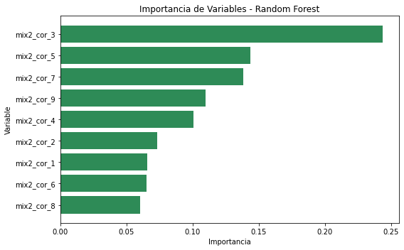

```python
# 5. IMPORTANCIA DE VARIABLES
# -------------------------------------------------------
importancias = pd.DataFrame({
    'Variable': X.columns,
    'Importancia': rf.feature_importances_
}).sort_values('Importancia', ascending=False)

plt.figure(figsize=(8, 5))
plt.barh(importancias['Variable'], importancias['Importancia'], color='seagreen')
plt.xlabel('Importancia')
plt.ylabel('Variable')
plt.title('Importancia de Variables - Random Forest')
plt.gca().invert_yaxis()
plt.tight_layout()
plt.show()
```

```python
# 7. APLICAR EL MODELO A LA IMAGEN COMPLETA (CORREGIDO)
# -------------------------------------------------------
with rasterio.open(ruta_tif) as src:
    img = src.read()  # (bandas, filas, columnas)
    profile = src.profile

print(f"Bandas en el raster: {img.shape[0]}")

# ⚠️ Si el raster tiene más de 9 bandas, tomamos solo las primeras 9
if img.shape[0] > 9:
    img = img[:9, :, :]  # quedarnos solo con las bandas relevantes

# Transponer para tener (pixeles, bandas)
n_bands, n_rows, n_cols = img.shape
stacked = img.reshape(n_bands, -1).T

# Convertir a DataFrame con los mismos nombres que en el entrenamiento
X_raster = pd.DataFrame(stacked, columns=[
    'mix2_cor_1', 'mix2_cor_2', 'mix2_cor_3', 'mix2_cor_4',
    'mix2_cor_5', 'mix2_cor_6', 'mix2_cor_7', 'mix2_cor_8', 'mix2_cor_9'
])

# Reemplazar valores NaN o infinitos
X_raster = X_raster.replace([np.inf, -np.inf], np.nan).fillna(-9999)

# Predicción
pred = rf.predict(X_raster)

# Reconvertir a matriz (filas, columnas)
pred_reshaped = pred.reshape(n_rows, n_cols)
```

```
Bandas en el raster: 10
```

```
🗺️ Mapa de predicción guardado en: F:\proy vicuna\indices_1m\prediccion1_CarbonSto_RF.tif
```

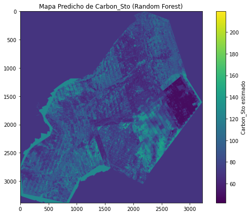

```python
# 8. GUARDAR Y VISUALIZAR MAPA DE PREDICCIÓN
# -------------------------------------------------------
output_raster = r"F:\proy vicuna\indices_1m\prediccion1_CarbonSto_RF.tif"
profile.update(dtype=rasterio.float32, count=1)

with rasterio.open(output_raster, 'w', **profile) as dst:
    dst.write(pred_reshaped.astype(rasterio.float32), 1)

print("🗺️ Mapa de predicción guardado en:", output_raster)

# Visualización
plt.figure(figsize=(8, 6))
plt.imshow(pred_reshaped, cmap='viridis')
plt.colorbar(label='Carbon_Sto estimado')
plt.title("Mapa Predicho de Carbon_Sto (Random Forest)")
plt.tight_layout()
plt.show()
```

```python
import geopandas as gpd
import rasterio
from rasterio.plot import show
from rasterio.transform import from_origin
import numpy as np
import pandas as pd
from sklearn.preprocessing import StandardScaler
from sklearn.feature_selection import VarianceThreshold
from sklearn.model_selection import train_test_split, RandomizedSearchCV
from sklearn.ensemble import RandomForestRegressor
from sklearn.metrics import r2_score, mean_squared_error, mean_absolute_error
import matplotlib.pyplot as plt
import seaborn as sns
import joblib
import os

# -------------------------------------------------------
# 1. RUTAS DE ENTRADA Y SALIDA
# -------------------------------------------------------
ruta_shape = r"F:\proy vicuna\indices_1m\car_stn2_ind.shp"
ruta_tif   = r"F:\proy vicuna\indices_1m\mix2_ind_1m.tif"
ruta_salida_mapa = r"F:\proy vicuna\indices_1m\prediccion_carbono.tif"
ruta_modelo = r"F:\proy vicuna\indices_1m\modelo_rf_carbono.pkl"

# -------------------------------------------------------
# 2. CARGAR Y PREPROCESAR DATOS
# -------------------------------------------------------
print("Cargando shapefile...")
gdf = gpd.read_file(ruta_shape)

vars_predictoras = [
    'mix2_cor_1','mix2_cor_2','mix2_cor_3','mix2_cor_4','mix2_cor_5',
    'mix2_cor_6','mix2_cor_7','mix2_cor_8','mix2_cor_9'
]

# Convertir a tipo numérico forzando errores a NaN
for col in vars_predictoras + ['Carbon_Sto']:
    gdf[col] = pd.to_numeric(gdf[col], errors='coerce')

# Extraer X y y
X = gdf[vars_predictoras].values
y = gdf['Carbon_Sto'].values

# Eliminar filas con NaN o infinitos
mask = np.isfinite(X).all(axis=1) & np.isfinite(y)
X, y = X[mask], y[mask]
print(f"Datos válidos: {X.shape[0]} muestras")

# Escalamiento
scaler = StandardScaler()
X_scaled = scaler.fit_transform(X)

# Eliminación de baja varianza
sel = VarianceThreshold(threshold=0.01)
X_sel = sel.fit_transform(X_scaled)
selected_features = np.array(vars_predictoras)[sel.get_support()]
print("Variables retenidas:", selected_features)

# -------------------------------------------------------
# 3. ENTRENAMIENTO DEL MODELO
# -------------------------------------------------------
X_train, X_test, y_train, y_test = train_test_split(
    X_sel, y, test_size=0.2, random_state=42
)

rf = RandomForestRegressor(random_state=42)
param_distrib = {
    'n_estimators': [100, 200, 300, 400, 500],
    'max_depth': [5, 10, 20, 30, None],
    'min_samples_split': [2, 4, 6, 8],
    'min_samples_leaf': [1, 2, 4],
    'max_features': ['sqrt', 'log2']
}

search = RandomizedSearchCV(
    rf, param_distributions=param_distrib,
    n_iter=30, cv=5, n_jobs=-1, random_state=42, verbose=1
)
search.fit(X_train, y_train)

best_rf = search.best_estimator_
print("Mejores parámetros:", search.best_params_)
```

```
Cargando shapefile...
Datos válidos: 81 muestras
Variables retenidas: ['mix2_cor_1' 'mix2_cor_2' 'mix2_cor_3' 'mix2_cor_4' 'mix2_cor_5'
 'mix2_cor_6' 'mix2_cor_7' 'mix2_cor_8' 'mix2_cor_9']
Fitting 5 folds for each of 30 candidates, totalling 150 fits
Mejores parámetros: {'n_estimators': 500, 'min_samples_split': 8, 'min_samples_leaf': 4, 'max_features': 'sqrt', 'max_depth': 30}
```

```
R² = -0.413
RMSE = 52.586
MAE = 34.372
```

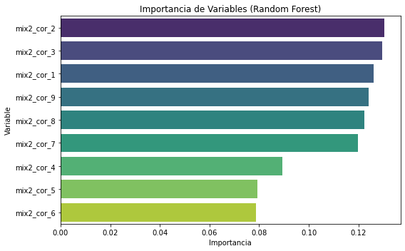

```
['F:\\proy vicuna\\indices_1m\\modelo_rf_carbono_scaler.pkl']
```

```python
# 4. EVALUACIÓN DEL MODELO
# -------------------------------------------------------
y_pred = best_rf.predict(X_test)
r2 = r2_score(y_test, y_pred)
rmse = np.sqrt(mean_squared_error(y_test, y_pred))
mae = mean_absolute_error(y_test, y_pred)

print(f"\nR² = {r2:.3f}")
print(f"RMSE = {rmse:.3f}")
print(f"MAE = {mae:.3f}")

# Importancia de variables
importancias = pd.DataFrame({
    'Variable': selected_features,
    'Importancia': best_rf.feature_importances_
}).sort_values('Importancia', ascending=False)

plt.figure(figsize=(8,5))
sns.barplot(data=importancias, x='Importancia', y='Variable', palette='viridis')
plt.title("Importancia de Variables (Random Forest)")
plt.tight_layout()
plt.show()

# Guardar modelo y scaler
joblib.dump(best_rf, ruta_modelo)
joblib.dump(scaler, ruta_modelo.replace(".pkl", "_scaler.pkl"))
```

```python
# 5. PREDICCIÓN ESPACIAL SOBRE RASTER
# -------------------------------------------------------
print("Cargando raster para predicción...")
with rasterio.open(ruta_tif) as src:
    data = src.read()
    meta = src.meta

# Asegurar que las bandas coinciden con las variables seleccionadas
if data.shape[0] < len(selected_features):
    raise ValueError(f"El raster tiene {data.shape[0]} bandas, pero se necesitan {len(selected_features)}.")

# Crear matriz (n_pixeles x n_bandas)
n_bands = len(selected_features)
data_reshape = data[:n_bands].reshape(n_bands, -1).T

# Escalar los valores
data_scaled = scaler.transform(data_reshape)

# Predicción
print("Realizando predicciones...")
preds = best_rf.predict(data_scaled)

# Reconstruir a la forma del raster
pred_raster = preds.reshape(meta['height'], meta['width'])

# Actualizar metadatos
meta.update({
    "count": 1,
    "dtype": 'float32'
})
```

```
Cargando raster para predicción...
Realizando predicciones...
```

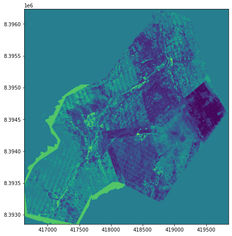

[figure not shown]

```python
# 6. VISUALIZAR MAPA DE PREDICCIÓN
# -------------------------------------------------------
plt.figure(figsize=(10,8))
show(pred_raster, transform=meta['transform'], cmap='viridis')
plt.title("Mapa de Predicción de Carbono (Mg/ha)")
plt.axis('off')
plt.show()
```

## Unir indices a resolucion 1m

```python
import rasterio
import numpy as np
```

```python
# Lista de rutas de tus archivos TIF
tif_paths = [
    r'F:\proy vicuna\indices_1m\NDGI_1m.tif',
    r'F:\proy vicuna\indices_1m\NDPI_1m.tif',
    r'F:\proy vicuna\indices_1m\NDSVI_1m.tif',
    r'F:\proy vicuna\indices_1m\TNDVI_1m.tif',
    r'F:\proy vicuna\indices_1m\NDVI_1m.tif',
    r'F:\proy vicuna\indices_1m\NDWI_1m.tif',
    r'F:\proy vicuna\indices_1m\CIgreen_1m.tif',
    r'F:\proy vicuna\indices_1m\OSAVI_1m.tif'
]

# Nombres descriptivos para cada banda
band_names = ['NDGI', 'NDPI', 'NDSVI', 'TNDVI', 'NDVI', 'NDWI', 'CIgreen', 'OSAVI']

# Leer arrays y perfil base
arrays = []
with rasterio.open(tif_paths[0]) as src_ref:
    profile = src_ref.profile.copy()
    profile.update(count=len(tif_paths))

    for path in tif_paths:
        with rasterio.open(path) as src:
            arrays.append(src.read(1))

# Stack de bandas
stacked = np.stack(arrays, axis=0)
```

```python
# Guardar como nuevo TIF multibanda
output_path = r'F:\proy vicuna\indices_1m\indices_mix1_1m.tif'
with rasterio.open(output_path, 'w', **profile) as dst:
    for i in range(len(tif_paths)):
        dst.write(stacked[i], i + 1)  # bandas comienzan en 1
```

## Pasar una imagen NDVI y Green a resolucion de 10m

```
Resolución original: (0.075, 0.0750000000000165)
CRS original: EPSG:32719
Dimensiones: 42975 x 45144
✅ Imagen reproyectada y guardada en: F:\proy vicuna\dron_10m\tambokarka-ndvi2-10m.tif
Valores únicos (muestra): [-0.18307875 -0.13376369 -0.13272281 -0.1136627  -0.10102767 -0.09998127
 -0.09987421 -0.09954976 -0.08813813 -0.0865637 ]
Mínimo: -0.18307875 Máximo: 0.6363987
```

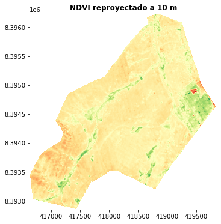

```python
import rasterio
from rasterio.warp import calculate_default_transform, reproject, Resampling
from rasterio.plot import show
import numpy as np
import matplotlib.pyplot as plt

# === Parámetros de entrada y salida ===
input_tif = r"C:\Users\User\Downloads\tambokarka-ndvi-unido.tif"
output_tif = r"F:\proy vicuna\dron_10m\tambokarka-ndvi2-10m.tif"

# === Parámetros destino ===
target_crs = "EPSG:32719"  # UTM 19S
target_resolution = 10  # metros

# === Leer imagen de entrada ===
with rasterio.open(input_tif) as src:
    print("Resolución original:", src.res)
    print("CRS original:", src.crs)
    print("Dimensiones:", src.width, "x", src.height)

    # Asignar CRS si no existe
    if src.crs is None:
        print("⚠️ No se detectó CRS. Asignando EPSG:4326 (WGS84)...")
        src_crs = rasterio.crs.CRS.from_epsg(4326)
    else:
        src_crs = src.crs

    # Calcular transform y tamaño de salida
    transform, width, height = calculate_default_transform(
        src_crs,
        target_crs,
        src.width,
        src.height,
        *src.bounds,
        resolution=target_resolution
    )

    # Crear nuevo perfil
    kwargs = src.meta.copy()
    kwargs.update({
        'crs': target_crs,
        'transform': transform,
        'width': width,
        'height': height,
        'nodata': np.nan,
        'dtype': 'float32',
        'driver': 'GTiff'
    })

    # Reproyectar y guardar
    with rasterio.open(output_tif, 'w', **kwargs) as dst:
        for i in range(1, src.count + 1):
            reproject(
                source=rasterio.band(src, i),
                destination=rasterio.band(dst, i),
                src_transform=src.transform,
                src_crs=src_crs,
                dst_transform=transform,
                dst_crs=target_crs,
                resampling=Resampling.bilinear
            )

print("✅ Imagen reproyectada y guardada en:", output_tif)

# === Verificar si tiene datos ===
with rasterio.open(output_tif) as dst:
    arr = dst.read(1)
    print("Valores únicos (muestra):", np.unique(arr[~np.isnan(arr)])[:10])
    print("Mínimo:", np.nanmin(arr), "Máximo:", np.nanmax(arr))

    # Mostrar mapa
    plt.figure(figsize=(8, 6))
    show(dst, cmap='RdYlGn', title="NDVI reproyectado a 10 m")
    plt.show()
```

```
Resolución original: (0.07499999999999946, 0.07500000000000825)
CRS original: EPSG:32719
Dimensiones: 42903 x 45107
✅ Imagen reproyectada y guardada en: F:\proy vicuna\dron_10m\tambokarka-green-10m.tif
Valores únicos (muestra): [0.01074484 0.01095372 0.01232487 0.01746611 0.0177545  0.01827197
 0.01929877 0.01972329 0.02168378 0.02176824]
Mínimo: 0.010744835 Máximo: 0.7475378
```

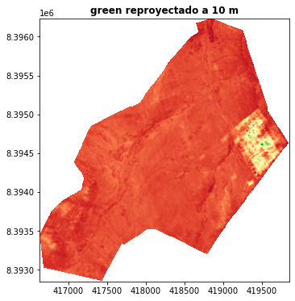

```python
import rasterio
from rasterio.warp import calculate_default_transform, reproject, Resampling
from rasterio.plot import show
import numpy as np
import matplotlib.pyplot as plt

# === Parámetros de entrada y salida ===
input_tif = r"C:\Users\User\Downloads\multi-green-tambo-UNIDO.tif"
output_tif = r"F:\proy vicuna\dron_10m\tambokarka-green-10m.tif"

# === Parámetros destino ===
target_crs = "EPSG:32719"  # UTM 19S
target_resolution = 10  # metros

# === Leer imagen de entrada ===
with rasterio.open(input_tif) as src:
    print("Resolución original:", src.res)
    print("CRS original:", src.crs)
    print("Dimensiones:", src.width, "x", src.height)

    # Asignar CRS si no existe
    if src.crs is None:
        print("⚠️ No se detectó CRS. Asignando EPSG:4326 (WGS84)...")
        src_crs = rasterio.crs.CRS.from_epsg(4326)
    else:
        src_crs = src.crs

    # Calcular transform y tamaño de salida
    transform, width, height = calculate_default_transform(
        src_crs,
        target_crs,
        src.width,
        src.height,
        *src.bounds,
        resolution=target_resolution
    )

    # Crear nuevo perfil
    kwargs = src.meta.copy()
    kwargs.update({
        'crs': target_crs,
        'transform': transform,
        'width': width,
        'height': height,
        'nodata': np.nan,
        'dtype': 'float32',
        'driver': 'GTiff'
    })

    # Reproyectar y guardar
    with rasterio.open(output_tif, 'w', **kwargs) as dst:
        for i in range(1, src.count + 1):
            reproject(
                source=rasterio.band(src, i),
                destination=rasterio.band(dst, i),
                src_transform=src.transform,
                src_crs=src_crs,
                dst_transform=transform,
                dst_crs=target_crs,
                resampling=Resampling.bilinear
            )

print("✅ Imagen reproyectada y guardada en:", output_tif)

# === Verificar si tiene datos ===
with rasterio.open(output_tif) as dst:
    arr = dst.read(1)
    print("Valores únicos (muestra):", np.unique(arr[~np.isnan(arr)])[:10])
    print("Mínimo:", np.nanmin(arr), "Máximo:", np.nanmax(arr))

    # Mostrar mapa
    plt.figure(figsize=(8, 6))
    show(dst, cmap='RdYlGn', title="green reproyectado a 10 m")
    plt.show()
```

## Unir tif a resolucion de 10m

```python
import rasterio
import numpy as np
```

```python
import rasterio
from rasterio.warp import reproject, Resampling
import numpy as np

# === Archivos fuente ===
green_path = r"F:\proy vicuna\dron_10m\tambokarka-green-10m.tif"
ndvi_path = r"F:\proy vicuna\dron_10m\tambokarka-ndvi2-10m.tif"
comb_path = r"F:\proy vicuna\sentinel_10m\comb_band_10m.tif"

# === Salida ===
output_path = r"F:\proy vicuna\multibandas_10m.tif"

# === Leer referencia base (Green) ===
with rasterio.open(green_path) as src_ref:
    profile = src_ref.profile.copy()
    ref_array = src_ref.read(1)
    ref_transform = src_ref.transform
    ref_crs = src_ref.crs
    ref_shape = ref_array.shape

arrays = [ref_array]  # Primera banda = Green

# === Función para alinear otras imágenes a la referencia ===
def reproject_to_ref(src_path, ref_shape, ref_transform, ref_crs):
    with rasterio.open(src_path) as src:
        data = src.read(1)
        dst = np.empty(ref_shape, dtype=np.float32)
        reproject(
            source=data,
            destination=dst,
            src_transform=src.transform,
            src_crs=src.crs,
            dst_transform=ref_transform,
            dst_crs=ref_crs,
            resampling=Resampling.bilinear
        )
    return dst

# === Añadir NDVI ===
ndvi_aligned = reproject_to_ref(ndvi_path, ref_shape, ref_transform, ref_crs)
arrays.append(ndvi_aligned)

# === Añadir bandas Sentinel (B5, B7, B11, B12) ===
with rasterio.open(comb_path) as src_comb:
    for band_index in [1, 2, 3, 4]:
        data = src_comb.read(band_index)
        dst = np.empty(ref_shape, dtype=np.float32)
        reproject(
            source=data,
            destination=dst,
            src_transform=src_comb.transform,
            src_crs=src_comb.crs,
            dst_transform=ref_transform,
            dst_crs=ref_crs,
            resampling=Resampling.bilinear
        )
        arrays.append(dst)

# === Crear stack multibanda ===
stacked = np.stack(arrays, axis=0)

# === Actualizar perfil ===
profile.update(
    count=len(arrays),
    dtype='float32',
    compress='lzw'
)

# === Guardar nuevo GeoTIFF ===
with rasterio.open(output_path, 'w', **profile) as dst:
    for i in range(stacked.shape[0]):
        dst.write(stacked[i].astype('float32'), i + 1)

print(f"✅ Archivo creado correctamente: {output_path}")
print("Bandas incluidas: [Green, NDVI, B5, B7, B11, B12]")
```

```
✅ Archivo creado correctamente: F:\proy vicuna\multibandas_10m.tif
Bandas incluidas: [Green, NDVI, B5, B7, B11, B12]
```

```python
import rasterio
import numpy as np
import os
from rasterio.warp import reproject, Resampling

# === Archivos de entrada ===
green_path = r"F:\proy vicuna\dron_10m\tambokarka-green-10m.tif"
ndvi_path = r"F:\proy vicuna\dron_10m\tambokarka-ndvi2-10m.tif"
sentinel_path = r"F:\proy vicuna\sentinel_10m\comb_band_10m.tif"

# === Leer imágenes ===
arrays = []
with rasterio.open(green_path) as src_green, \
     rasterio.open(ndvi_path) as src_ndvi, \
     rasterio.open(sentinel_path) as src_sen:

    # Base (resolución, CRS, transform)
    base_meta = src_green.meta.copy()

    # Asegurar mismo tamaño
    green = src_green.read(1)

    # Reproyectar NDVI al mismo grid del Green
    ndvi = np.zeros_like(green, dtype=np.float32)
    reproject(
        source=src_ndvi.read(1),
        destination=ndvi,
        src_transform=src_ndvi.transform,
        src_crs=src_ndvi.crs,
        dst_transform=src_green.transform,
        dst_crs=src_green.crs,
        resampling=Resampling.bilinear
    )

    # Reproyectar bandas Sentinel (B5, B7, B11, B12)
    sentinel_bands = []
    for i in range(1, src_sen.count + 1):
        band = np.zeros_like(green, dtype=np.float32)
        reproject(
            source=src_sen.read(i),
            destination=band,
            src_transform=src_sen.transform,
            src_crs=src_sen.crs,
            dst_transform=src_green.transform,
            dst_crs=src_green.crs,
            resampling=Resampling.bilinear
        )
        sentinel_bands.append(band)

    # Crear lista de bandas finales
    arrays = [green, ndvi] + sentinel_bands

# === Apilar ===
stacked = np.stack(arrays, axis=0)

# === Actualizar metadatos ===
profile = base_meta.copy()
profile.update(count=stacked.shape[0], dtype='float32', compress='lzw', nodata=np.nan)

# === Ruta de salida ===
output_path = r"F:\proy vicuna\multibandas1_10m.tif"

# Crear carpeta si no existe
os.makedirs(os.path.dirname(output_path), exist_ok=True)

# === Guardar nuevo GeoTIFF ===
band_names = ['Green', 'NDVI', 'B5', 'B7', 'B11', 'B12']

with rasterio.open(output_path, 'w', **profile) as dst:
    for i, band_name in enumerate(band_names):
        dst.write(stacked[i].astype('float32'), i + 1)
        dst.set_band_description(i + 1, band_name)  # 💡 Etiqueta visible en QGIS

print("✅ Archivo creado correctamente en:", output_path)
print("🛰️ Bandas guardadas:", band_names)
```

```
✅ Archivo creado correctamente en: F:\proy vicuna\multibandas1_10m.tif
🛰️ Bandas guardadas: ['Green', 'NDVI', 'B5', 'B7', 'B11', 'B12']
```

```python
# ================================================================
# 📘 PREDICCIÓN DE CARBON_Sto USANDO RANDOM FOREST
# ================================================================

import geopandas as gpd
import rasterio
import numpy as np
import matplotlib.pyplot as plt
import pandas as pd
from sklearn.ensemble import RandomForestRegressor
from sklearn.model_selection import train_test_split
from sklearn.metrics import r2_score, mean_squared_error, mean_absolute_error
import joblib

# ================================================================
# 1️⃣ CARGAR DATOS
# ================================================================
ruta_shape = r"F:\proy vicuna\dron_10m\shp_10m\puntos_10m.shp"
ruta_tif   = r"F:\proy vicuna\multibandas1_10m.tif"

gdf = gpd.read_file(ruta_shape)
print("Columnas disponibles en el shapefile:")
print(gdf.columns)

# Variables predictoras (ajusta nombres según tu shapefile)
variables = ['ban_green', 'ban_ndvi', 'ban_5', 'ban_7', 'ban_11', 'ban_12']
X = gdf[variables].copy()
y = gdf['Carbon_Sto'].copy()

# Eliminar filas con valores nulos
mask = X.notnull().all(axis=1) & y.notnull()
X = X[mask]
y = y[mask]

print(f"Datos válidos para entrenamiento: {len(X)} muestras")
```

```
Columnas disponibles en el shapefile:
Index(['Elevation', 'Carbon_Sto', 'ban_green', 'ban_ndvi', 'ban_5', 'ban_7',
       'ban_11', 'ban_12', 'geometry'],
      dtype='object')
Datos válidos para entrenamiento: 76 muestras
```

```python
# 2️⃣ DIVISIÓN ENTRENAMIENTO / PRUEBA
# ================================================================
X_train, X_test, y_train, y_test = train_test_split(
    X, y, test_size=0.3, random_state=42
)

# ================================================================
# 3️⃣ ENTRENAR MODELO RANDOM FOREST
# ================================================================
rf = RandomForestRegressor(
    n_estimators=300,
    max_depth=15,
    random_state=42,
    n_jobs=-1
)
rf.fit(X_train, y_train)
```

```
RandomForestRegressor(max_depth=15, n_estimators=300, n_jobs=-1,
                      random_state=42)
```

```python
# Guardar modelo entrenado
##joblib.dump(rf, r"F:\proy vicuna\modelo_RF_CarbonSto.pkl")

# ================================================================
# 4️⃣ EVALUACIÓN DEL MODELO
# ================================================================
y_pred = rf.predict(X_test)
r2 = r2_score(y_test, y_pred)
rmse = mean_squared_error(y_test, y_pred, squared=False)
mae = mean_absolute_error(y_test, y_pred)

print("\n📊 MÉTRICAS DE VALIDACIÓN:")
print(f"R²:   {r2:.3f}")
print(f"RMSE: {rmse:.3f}")
print(f"MAE:  {mae:.3f}")
```

```
📊 MÉTRICAS DE VALIDACIÓN:
R²:   0.541
RMSE: 67.687
MAE:  54.873
```

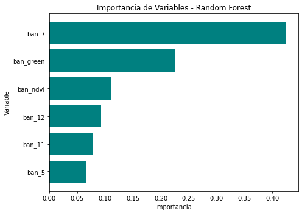

```
Importancia de variables:
     Variable  Importancia
3      ban_7     0.424828
0  ban_green     0.225286
1   ban_ndvi     0.111589
5     ban_12     0.093416
4     ban_11     0.078440
2      ban_5     0.066441
```

```python
# ================================================================
# 5️⃣ IMPORTANCIA DE VARIABLES
# ================================================================
importancias = pd.DataFrame({
    'Variable': X.columns,
    'Importancia': rf.feature_importances_
}).sort_values('Importancia', ascending=False)

plt.figure(figsize=(7, 5))
plt.barh(importancias['Variable'], importancias['Importancia'], color='teal')
plt.xlabel('Importancia')
plt.ylabel('Variable')
plt.title('Importancia de Variables - Random Forest')
plt.gca().invert_yaxis()
plt.tight_layout()
plt.show()

print("\nImportancia de variables:\n", importancias)
```

```python
# 6️⃣ APLICAR MODELO A RASTER MULTIBANDA
# ================================================================
with rasterio.open(ruta_tif) as src:
    img = src.read()  # (bandas, filas, columnas)
    profile = src.profile

print(f"\nBandas encontradas en el raster: {img.shape[0]}")

# ⚠️ IMPORTANTE: Asegura que las bandas del TIF sigan este orden:
# [Elevation, ban_green, ban_ndvi, ban_5, ban_7, ban_11, ban_12]

if img.shape[0] < len(variables):
    raise ValueError("El raster no contiene todas las bandas esperadas.")

# Reorganizar para obtener (pixeles, bandas)
n_bands, n_rows, n_cols = img.shape
stacked = img.reshape(n_bands, -1).T  # (pixeles, bandas)

# Crear DataFrame con los mismos nombres de entrenamiento
X_raster = pd.DataFrame(stacked, columns=variables)

# Manejar valores NaN e infinitos
X_raster = X_raster.replace([np.inf, -np.inf], np.nan).fillna(-9999)

# Predicción sobre todos los píxeles
pred = rf.predict(X_raster)

# Reconvertir a matriz (filas, columnas)
pred_reshaped = pred.reshape(n_rows, n_cols)
```

```
Bandas encontradas en el raster: 6
```

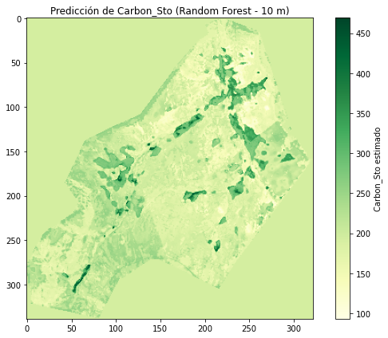

```python
# 8️⃣ VISUALIZACIÓN FINAL
# ================================================================
plt.figure(figsize=(8, 6))
plt.imshow(pred_reshaped, cmap='YlGn')
plt.colorbar(label='Carbon_Sto estimado')
plt.title("Predicción de Carbon_Sto (Random Forest - 10 m)")
plt.tight_layout()
plt.show()
```

## Usando SVM

```python
# 🔹 SVM de regresión para estimar Carbon_Sto a partir de bandas
# ============================================================

import geopandas as gpd
import rasterio
import numpy as np
import matplotlib.pyplot as plt
import pandas as pd
from sklearn.svm import SVR
from sklearn.model_selection import train_test_split
from sklearn.metrics import r2_score, mean_squared_error, mean_absolute_error
import joblib

# -------------------------------------------------------
# 1. CARGAR DATOS
# -------------------------------------------------------
ruta_shape = r"F:\proy vicuna\dron_10m\shp_10m\puntos_10m.shp"
ruta_tif   = r"F:\proy vicuna\multibandas1_10m.tif"

gdf = gpd.read_file(ruta_shape)
print("Columnas disponibles en el shapefile:", gdf.columns)

# Variables predictoras y variable objetivo
variables = ['ban_5', 'ban_7', 'ban_11', 'ban_12', 'ban_ndvi', 'ban_green']
X = gdf[variables].copy()
y = gdf['Carbon_Sto'].copy()

# Eliminar filas con NaN
mask = X.notnull().all(axis=1) & y.notnull()
X = X[mask]
y = y[mask]

# -------------------------------------------------------
# 2. DIVISIÓN EN ENTRENAMIENTO Y PRUEBA
# -------------------------------------------------------
X_train, X_test, y_train, y_test = train_test_split(
    X, y, test_size=0.3, random_state=42
)

# -------------------------------------------------------
# 3. ENTRENAR MODELO SVM REGRESIÓN
# -------------------------------------------------------
print("\nEntrenando modelo SVM...")
svm = SVR(kernel='rbf', C=100, gamma=0.1, epsilon=0.1)
svm.fit(X_train, y_train)

# -------------------------------------------------------
# 4. EVALUACIÓN
# -------------------------------------------------------
y_pred = svm.predict(X_test)
r2 = r2_score(y_test, y_pred)
rmse = mean_squared_error(y_test, y_pred, squared=False)
mae = mean_absolute_error(y_test, y_pred)

print("\n📊 Métricas de validación:")
print(f"R²:   {r2:.3f}")
print(f"RMSE: {rmse:.3f}")
print(f"MAE:  {mae:.3f}")
```

```
Columnas disponibles en el shapefile: Index(['Carbon_Sto', 'ban_green', 'ban_ndvi', 'ban_5', 'ban_7', 'ban_11',
       'ban_12', 'geometry'],
      dtype='object')

Entrenando modelo SVM...

📊 Métricas de validación:
R²:   -0.005
RMSE: 100.182
MAE:  69.250
```

```python
# 6. APLICAR EL MODELO AL RASTER COMPLETO (autodetección)
# -------------------------------------------------------
print("\nAplicando modelo SVM al raster...")

with rasterio.open(ruta_tif) as src:
    img = src.read()  # (bandas, filas, columnas)
    profile = src.profile
    print(f"Bandas encontradas en el raster: {img.shape[0]}")
    print("Descripciones (si existen):", src.descriptions)

# Detectar automáticamente si hay una banda extra
if img.shape[0] != len(variables):
    print(f"⚠️ El raster tiene {img.shape[0]} bandas, pero el modelo usa {len(variables)} variables.")
    print("Se usará automáticamente el subconjunto de bandas que coincide en número.")
    # Seleccionar las 5 primeras bandas para que coincidan
    img = img[:len(variables), :, :]

# Reorganizar a (pixeles, bandas)
n_bands, n_rows, n_cols = img.shape
stacked = img.reshape(n_bands, -1).T  # (pixeles, bandas)

# Crear DataFrame con las variables esperadas
X_raster = pd.DataFrame(stacked, columns=variables)
X_raster = X_raster.replace([np.inf, -np.inf], np.nan).fillna(-9999)
```

```
Aplicando modelo SVM al raster...
Bandas encontradas en el raster: 6
Descripciones (si existen): ('Green', 'NDVI', 'B5', 'B7', 'B11', 'B12')
```

[figure not shown]

```python
# 8. VISUALIZACIÓN DEL MAPA
# -------------------------------------------------------
plt.figure(figsize=(8, 6))
plt.imshow(pred_reshaped, cmap='viridis')
plt.colorbar(label='Carbon_Sto estimado (SVM)')
plt.title("Mapa Predicho de Carbon_Sto - SVM")
plt.tight_layout()
plt.show()
```

## Cambiar los indices de 1m a 10m

```
=== Procesando NDGI ===
Resolución original: (0.9999999999999928, 1.0000000000001101)
Dimensiones originales: 3217 x 3383
✅ Guardado: F:\proy vicuna\indices_10m\NDGI_10m.tif
Valores (muestra): [-0.7720399  -0.7708679  -0.76884276 -0.76650995 -0.7643196 ]
Rango: -0.7720399 → 1.0
```

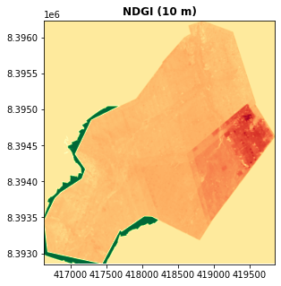

```
=== Procesando NDPI ===
Resolución original: (0.9999999999999928, 1.0000000000001101)
Dimensiones originales: 3217 x 3383
✅ Guardado: F:\proy vicuna\indices_10m\NDPI_10m.tif
Valores (muestra): [-1.         -0.999975   -0.9999713  -0.9999709  -0.99997026]
Rango: -1.0 → 1.0
```

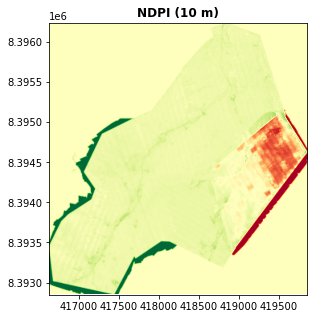

```
=== Procesando NDSVI ===
Resolución original: (0.9999999999999928, 1.0000000000001101)
Dimensiones originales: 3217 x 3383
✅ Guardado: F:\proy vicuna\indices_10m\NDSVI_10m.tif
Valores (muestra): [-1.        -0.999975  -0.9999644 -0.999963  -0.9999628]
Rango: -1.0 → 0.6884751
```

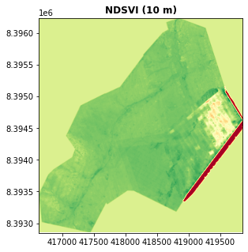

```
=== Procesando TNDVI ===
Resolución original: (0.9999999999999928, 1.0000000000001101)
Dimensiones originales: 3217 x 3383
✅ Guardado: F:\proy vicuna\indices_10m\TNDVI_10m.tif
Valores (muestra): [0.54703754 0.55169284 0.59101653 0.59113246 0.59495735]
Rango: 0.54703754 → 1.2247449
```

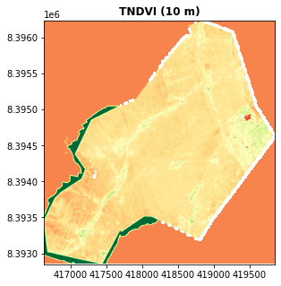

```
=== Procesando NDVI ===
Resolución original: (0.9999999999999928, 1.0000000000001101)
Dimensiones originales: 3217 x 3383
✅ Guardado: F:\proy vicuna\indices_10m\NDVI_10m.tif
Valores (muestra): [-0.19358006 -0.18496627 -0.14650409 -0.13691622 -0.12933083]
Rango: -0.19358006 → 1.0
```

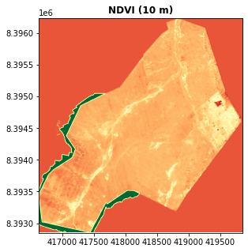

```
=== Procesando NDWI ===
Resolución original: (0.9999999999999928, 1.0000000000001101)
Dimensiones originales: 3217 x 3383
✅ Guardado: F:\proy vicuna\indices_10m\NDWI_10m.tif
Valores (muestra): [-0.83407056 -0.8315934  -0.82413673 -0.8238339  -0.8230268 ]
Rango: -0.83407056 → 0.0
```

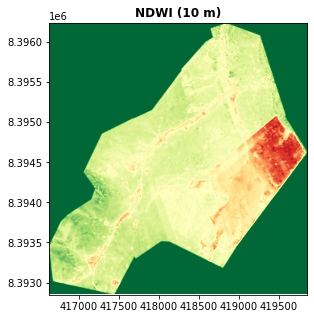

```
=== Procesando CIgreen ===
Resolución original: (0.9999999999999928, 1.0000000000001101)
Dimensiones originales: 3217 x 3383
✅ Guardado: F:\proy vicuna\indices_10m\CIgreen_10m.tif
Valores (muestra): [0.00000000e+00 9.33534466e-06 1.26834393e-05 1.44613805e-05
 1.44709948e-05]
Rango: 0.0 → 10.630057
```

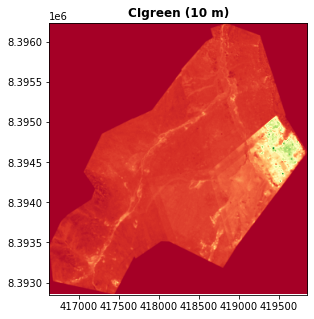

```
=== Procesando OSAVI ===
Resolución original: (0.9999999999999928, 1.0000000000001101)
Dimensiones originales: 3217 x 3383
✅ Guardado: F:\proy vicuna\indices_10m\OSAVI_10m.tif
Valores (muestra): [-0.21100184 -0.2082148  -0.15880841 -0.1367844  -0.13635296]
Rango: -0.21100184 → 1.16
```

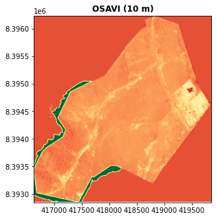

```
🎯 Todos los archivos han sido reproyectados a 10 m correctamente.
```

```python
import rasterio
from rasterio.warp import calculate_default_transform, reproject, Resampling
import numpy as np
import os
from rasterio.plot import show
import matplotlib.pyplot as plt

# === Lista de archivos TIF de entrada ===
tif_paths = [
    r'F:\proy vicuna\indices_1m\NDGI_1m.tif',
    r'F:\proy vicuna\indices_1m\NDPI_1m.tif',
    r'F:\proy vicuna\indices_1m\NDSVI_1m.tif',
    r'F:\proy vicuna\indices_1m\TNDVI_1m.tif',
    r'F:\proy vicuna\indices_1m\NDVI_1m.tif',
    r'F:\proy vicuna\indices_1m\NDWI_1m.tif',
    r'F:\proy vicuna\indices_1m\CIgreen_1m.tif',
    r'F:\proy vicuna\indices_1m\OSAVI_1m.tif'
]

# === Nombres descriptivos (para mostrar y guardar) ===
band_names = ['NDGI', 'NDPI', 'NDSVI', 'TNDVI', 'NDVI', 'NDWI', 'CIgreen', 'OSAVI']

# === Carpeta de salida ===
output_folder = r'F:\proy vicuna\indices_10m'
os.makedirs(output_folder, exist_ok=True)

# === Parámetros destino ===
target_crs = "EPSG:32719"  # UTM 19S
target_resolution = 10  # metros

# === Procesar cada archivo ===
for tif_path, band_name in zip(tif_paths, band_names):
    output_tif = os.path.join(output_folder, f"{band_name}_10m.tif")
    print(f"\n=== Procesando {band_name} ===")

    with rasterio.open(tif_path) as src:
        print("Resolución original:", src.res)
        print("Dimensiones originales:", src.width, "x", src.height)

        # Si no tiene CRS, se asigna uno base (WGS84)
        if src.crs is None:
            print("⚠️ No se detectó CRS. Asignando EPSG:4326 (WGS84)...")
            src_crs = rasterio.crs.CRS.from_epsg(4326)
        else:
            src_crs = src.crs

        # Calcular nuevo transform, ancho y alto
        transform, width, height = calculate_default_transform(
            src_crs,
            target_crs,
            src.width,
            src.height,
            *src.bounds,
            resolution=target_resolution
        )

        # Crear nuevo perfil de salida
        kwargs = src.meta.copy()
        kwargs.update({
            'crs': target_crs,
            'transform': transform,
            'width': width,
            'height': height,
            'nodata': np.nan,
            'dtype': 'float32',
            'driver': 'GTiff'
        })

        # Reproyectar
        with rasterio.open(output_tif, 'w', **kwargs) as dst:
            for i in range(1, src.count + 1):
                reproject(
                    source=rasterio.band(src, i),
                    destination=rasterio.band(dst, i),
                    src_transform=src.transform,
                    src_crs=src_crs,
                    dst_transform=transform,
                    dst_crs=target_crs,
                    resampling=Resampling.bilinear
                )

    print(f"✅ Guardado: {output_tif}")

    # --- Verificar datos ---
    with rasterio.open(output_tif) as dst:
        arr = dst.read(1)
        print("Valores (muestra):", np.unique(arr[~np.isnan(arr)])[:5])
        print("Rango:", np.nanmin(arr), "→", np.nanmax(arr))

        # Mostrar mapa pequeño opcional
        plt.figure(figsize=(6, 5))
        show(dst, cmap='RdYlGn', title=f"{band_name} (10 m)")
        plt.show()

print("\n🎯 Todos los archivos han sido reproyectados a 10 m correctamente.")
```

```python
import rasterio
from rasterio.mask import mask
import geopandas as gpd
import os

# === RUTAS ===
rutas_tif = [
    r"F:\proy vicuna\indices_10m\TNDVI_10m.tif",
    r"F:\proy vicuna\indices_10m\NDWI_10m.tif",
    r"F:\proy vicuna\indices_10m\CIgreen_10m.tif",
    r"F:\proy vicuna\indices_10m\OSAVI_10m.tif"
]

ruta_shape = r"F:\proy vicuna\04_Sectors\Tambokarkas5.shp"
ruta_salida = r"F:\proy vicuna\indices_10m\img_cortada"

# Crear carpeta de salida si no existe
os.makedirs(ruta_salida, exist_ok=True)

# === LEER SHAPE ===
shape = gpd.read_file(ruta_shape)

# === PROCESAR CADA RASTER ===
for ruta in rutas_tif:
    nombre = os.path.basename(ruta)
    salida = os.path.join(ruta_salida, f"clip_{nombre}")

    with rasterio.open(ruta) as src:
        # Obtener CRS del raster
        raster_crs = src.crs

        # Si el shapefile tiene otro CRS, reproyectarlo
        if shape.crs != raster_crs:
            shape = shape.to_crs(raster_crs)

        geoms = [feature.__geo_interface__ for feature in shape.geometry]

        try:
            out_image, out_transform = mask(src, geoms, crop=True)
        except ValueError:
            print(f"⚠️ El shapefile no se superpone con {nombre}. Saltando...")
            continue

        out_meta = src.meta.copy()
        out_meta.update({
            "driver": "GTiff",
            "height": out_image.shape[1],
            "width": out_image.shape[2],
            "transform": out_transform
        })

        with rasterio.open(salida, "w", **out_meta) as dest:
            dest.write(out_image)

    print(f"✅ Imagen recortada guardada en: {salida}")

print("🎯 Proceso completado.")
```

```
✅ Imagen recortada guardada en: F:\proy vicuna\indices_10m\img_cortada\clip_TNDVI_10m.tif
✅ Imagen recortada guardada en: F:\proy vicuna\indices_10m\img_cortada\clip_NDWI_10m.tif
✅ Imagen recortada guardada en: F:\proy vicuna\indices_10m\img_cortada\clip_CIgreen_10m.tif
✅ Imagen recortada guardada en: F:\proy vicuna\indices_10m\img_cortada\clip_OSAVI_10m.tif
🎯 Proceso completado.
```

```python
import rasterio
import numpy as np
import os
from rasterio.warp import reproject, Resampling

# === Archivos de entrada ===
green_path = r"F:\proy vicuna\dron_10m\tambokarka-green-10m.tif"
ndvi_path = r"F:\proy vicuna\dron_10m\tambokarka-ndvi2-10m.tif"
sentinel_path = r"F:\proy vicuna\sentinel_10m\comb_band_10m.tif"

# === Nuevos índices a agregar ===
tndvi_10 = r"F:\proy vicuna\indices_10m\img_cortada\clip_TNDVI_10m.tif"
ndwi_10  = r"F:\proy vicuna\indices_10m\img_cortada\clip_NDWI_10m.tif"
cig_10   = r"F:\proy vicuna\indices_10m\img_cortada\clip_CIgreen_10m.tif"
osavi_10 = r"F:\proy vicuna\indices_10m\img_cortada\clip_OSAVI_10m.tif"

# === Salida ===
output_path = r"F:\proy vicuna\multibandas3_10m.tif"
os.makedirs(os.path.dirname(output_path), exist_ok=True)

# === Leer imágenes base ===
arrays = []
band_names = []

with rasterio.open(green_path) as src_green, \
     rasterio.open(ndvi_path) as src_ndvi, \
     rasterio.open(sentinel_path) as src_sen:

    # Base: usar Green como referencia (CRS, resolución, transform)
    base_meta = src_green.meta.copy()
    green = src_green.read(1)
    arrays.append(green)
    band_names.append("Green")

    # === NDVI ===
    ndvi = np.zeros_like(green, dtype=np.float32)
    reproject(
        source=src_ndvi.read(1),
        destination=ndvi,
        src_transform=src_ndvi.transform,
        src_crs=src_ndvi.crs,
        dst_transform=src_green.transform,
        dst_crs=src_green.crs,
        resampling=Resampling.bilinear
    )
    arrays.append(ndvi)
    band_names.append("NDVI")

    # === Sentinel (4 bandas: B5, B7, B11, B12) ===
    sentinel_labels = ["B5", "B7", "B11", "B12"]
    for i, label in enumerate(sentinel_labels, start=1):
        band = np.zeros_like(green, dtype=np.float32)
        reproject(
            source=src_sen.read(i),
            destination=band,
            src_transform=src_sen.transform,
            src_crs=src_sen.crs,
            dst_transform=src_green.transform,
            dst_crs=src_green.crs,
            resampling=Resampling.bilinear
        )
        arrays.append(band)
        band_names.append(label)

# === Agregar índices adicionales ===
extra_tifs = {
    "TNDVI": tndvi_10,
    "NDWI": ndwi_10,
    "CIgreen": cig_10,
    "OSAVI": osavi_10
}

for name, ruta in extra_tifs.items():
    with rasterio.open(ruta) as src:
        band = np.zeros_like(green, dtype=np.float32)
        reproject(
            source=src.read(1),
            destination=band,
            src_transform=src.transform,
            src_crs=src.crs,
            dst_transform=base_meta["transform"],
            dst_crs=base_meta["crs"],
            resampling=Resampling.bilinear
        )
        arrays.append(band)
        band_names.append(name)

# === Apilar todas las bandas ===
stacked = np.stack(arrays, axis=0)

# === Actualizar metadatos ===
profile = base_meta.copy()
profile.update(
    count=stacked.shape[0],
    dtype='float32',
    compress='lzw',
    nodata=np.nan
)

# === Guardar GeoTIFF ===
with rasterio.open(output_path, 'w', **profile) as dst:
    for i, name in enumerate(band_names):
        dst.write(stacked[i].astype('float32'), i + 1)
        dst.set_band_description(i + 1, name)

print("✅ Archivo multibanda creado correctamente en:")
print(output_path)
print("🛰️ Bandas guardadas:", band_names)
print("📏 Dimensiones (bandas, filas, columnas):", stacked.shape)
```

```
✅ Archivo multibanda creado correctamente en:
F:\proy vicuna\multibandas3_10m.tif
🛰️ Bandas guardadas: ['Green', 'NDVI', 'B5', 'B7', 'B11', 'B12', 'TNDVI', 'NDWI', 'CIgreen', 'OSAVI']
📏 Dimensiones (bandas, filas, columnas): (10, 339, 322)
```

```python
# ================================================================
# 📘 PREDICCIÓN DE CARBON_Sto USANDO RANDOM FOREST
# ================================================================

import geopandas as gpd
import rasterio
import numpy as np
import matplotlib.pyplot as plt
import pandas as pd
from sklearn.ensemble import RandomForestRegressor
from sklearn.model_selection import train_test_split
from sklearn.metrics import r2_score, mean_squared_error, mean_absolute_error
import joblib

# ================================================================
# 1️⃣ CARGAR DATOS
# ================================================================
ruta_shape = r"F:\proy vicuna\indices_10m\mix_3.shp"
ruta_tif   = r"F:\proy vicuna\multibandas3_10m.tif"

gdf = gpd.read_file(ruta_shape)
print("Columnas disponibles en el shapefile:")
print(gdf.columns)
```

```
Columnas disponibles en el shapefile:
Index(['Carbon_Sto', 'b_green', 'b_ndvi', 'b_7', 'b_12', 'b_ndwi', 'b_cigre',
       'b_osavi', 'geometry'],
      dtype='object')
```

```python
# Variables predictoras (ajusta nombres según tu shapefile)
variables = ['b_green', 'b_ndvi', 'b_7', 'b_12', 'b_ndwi', 'b_cigre', 'b_osavi']
X = gdf[variables].copy()
y = gdf['Carbon_Sto'].copy()

# Eliminar filas con valores nulos
mask = X.notnull().all(axis=1) & y.notnull()
X = X[mask]
y = y[mask]

print(f"Datos válidos para entrenamiento: {len(X)} muestras")


# 2️⃣ DIVISIÓN ENTRENAMIENTO / PRUEBA
# ================================================================
X_train, X_test, y_train, y_test = train_test_split(
    X, y, test_size=0.3, random_state=42
)

# ================================================================
# 3️⃣ ENTRENAR MODELO RANDOM FOREST
# ================================================================
rf = RandomForestRegressor(
    n_estimators=300,
    max_depth=15,
    random_state=42,
    n_jobs=-1
)
rf.fit(X_train, y_train)
```

```
Datos válidos para entrenamiento: 75 muestras
```

```
RandomForestRegressor(max_depth=15, n_estimators=300, n_jobs=-1,
                      random_state=42)
```

```python
# Guardar modelo entrenado
##joblib.dump(rf, r"F:\proy vicuna\modelo_RF_CarbonSto.pkl")

# ================================================================
# 4️⃣ EVALUACIÓN DEL MODELO
# ================================================================
y_pred = rf.predict(X_test)
r2 = r2_score(y_test, y_pred)
rmse = mean_squared_error(y_test, y_pred, squared=False)
mae = mean_absolute_error(y_test, y_pred)

print("\n📊 MÉTRICAS DE VALIDACIÓN:")
print(f"R²:   {r2:.3f}")
print(f"RMSE: {rmse:.3f}")
print(f"MAE:  {mae:.3f}")
```

```
📊 MÉTRICAS DE VALIDACIÓN:
R²:   0.531
RMSE: 68.084
MAE:  53.763
```

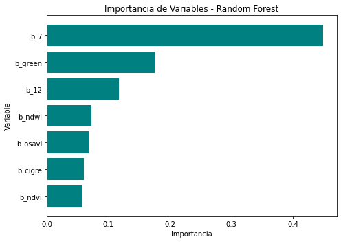

```
Importancia de variables:
   Variable  Importancia
2      b_7     0.448727
0  b_green     0.175373
3     b_12     0.117225
4   b_ndwi     0.072539
6  b_osavi     0.067518
5  b_cigre     0.060549
1   b_ndvi     0.058069
```

```python
# ================================================================
# 5️⃣ IMPORTANCIA DE VARIABLES
# ================================================================
importancias = pd.DataFrame({
    'Variable': X.columns,
    'Importancia': rf.feature_importances_
}).sort_values('Importancia', ascending=False)

plt.figure(figsize=(7, 5))
plt.barh(importancias['Variable'], importancias['Importancia'], color='teal')
plt.xlabel('Importancia')
plt.ylabel('Variable')
plt.title('Importancia de Variables - Random Forest')
plt.gca().invert_yaxis()
plt.tight_layout()
plt.show()

print("\nImportancia de variables:\n", importancias)
```

```python
# Resamplear DEM a 10 m

import rasterio
from rasterio.warp import calculate_default_transform, reproject, Resampling
import os

src_fp = r"C:\Users\User\Downloads\mdt-tambokarka-qgis.tif"
dst_fp = r"F:\proy vicuna\dron_10m\mdt-tambokarka_10m.tif"
target_resolution = 10.0

with rasterio.open(src_fp) as src:
    dst_crs = src.crs
    transform, width, height = calculate_default_transform(
        src.crs, dst_crs, src.width, src.height, *src.bounds, resolution=target_resolution)

    kwargs = src.meta.copy()
    kwargs.update({
        'crs': dst_crs,
        'transform': transform,
        'width': width,
        'height': height,
        'dtype': 'float32'
    })

    with rasterio.open(dst_fp, 'w', **kwargs) as dst:
        reproject(
            source=rasterio.band(src, 1),
            destination=rasterio.band(dst, 1),
            src_transform=src.transform,
            src_crs=src.crs,
            dst_transform=transform,
            dst_crs=dst_crs,
            resampling=Resampling.average)

print("✅ DEM re-muestreado guardado en:", dst_fp)
```

```
✅ DEM re-muestreado guardado en: F:\proy vicuna\dron_10m\mdt-tambokarka_10m.tif
```

# Rellenar sinks (depuraciones) y preparar DEM 10 m

# =======este paso lo hice en colab para no instalar esa libreria

# FillDepressions corrige pequeñas depresiones que romperían la continuidad del flujo.

# import whitebox

# wbt = whitebox.WhiteboxTools()

# in_dem = r"F:\proy vicuna\dron_10m\mdt-tambokarka_10m.tif"

# out_filled = r"F:\proy vicuna\dron_10m\mdt-tambokarka_10m_filled.tif"

# Rellenar depresiones

# wbt.fill_depressions(

# dem=in_dem,

# output=out_filled

# )

# print("✅ DEM filled guardado en:", out_filled)

```python
#Calcular pendiente (slope), dirección y acumulación de flujo (D8)
#lo hice en colab
import richdem as rd
import numpy as np
import rasterio

filled = r"F:\proy vicuna\dron_10m\mdt-tambokarka_10m_filled.tif"

rdem = rd.LoadGDAL(filled)

# 1) pendiente en grados
slope_deg = rd.TerrainAttribute(rdem, attrib='slope_degrees')  # array

# 2) dirección de flujo (D8)
fdir = rd.FlowDirectionD8(rdem)  # dirección por celda

# 3) acumulación de flujo (flow accumulation) con D8
fac = rd.FlowAccumulation(rdem, method='D8')  # número de celdas contribuyentes

# Guardar outputs (slope, fac) con rasterio (usando metadata del DEM)
import rasterio
from rasterio import Affine
with rasterio.open(filled) as src:
    meta = src.meta.copy()
    meta.update({'dtype': 'float32', 'count': 1, 'nodata': None})

    with rasterio.open(r"F:\proy vicuna\dron_10m\slope_10m.tif", 'w', **meta) as dst:
        dst.write(slope_deg.astype('float32'), 1)

    with rasterio.open(r"F:\proy vicuna\dron_10m\fac_10m.tif", 'w', **meta) as dst2:
        dst2.write(fac.astype('float32'), 1)

print("Pendiente y acumulación guardadas.")
```

# Calcular **LS** con la fórmula práctica (grilla de 10 m)

Fórmula práctica usada en implementaciones:

$$ \boxed{ LS=\left(\frac{A\cdot \text{cellsize}}{22.13}\right)^{m} \cdot \left(\frac{\sin(\beta)}{0.0896}\right)^{n} } $$

**donde:**

- (A): acumulación de flujo (número de celdas que contribuyen).  
  Para longitud en metros se usa (A \cdot \text{cellsize}).
- (\text{cellsize}=10\ \text{m}) (tamaño de celda).
- (\beta): pendiente en **radianes** (\big(\beta = \text{slope_deg} \cdot \pi/180\big)).
- (m, n): parámetros empíricos (p. ej., (m=0.4,\; n=1.3)).

```python
# --- Calcular el factor LS de la ecuación RUSLE en Colab ---
import rasterio
import numpy as np
import math

# === Entradas y salida ===
fac_fp = "F:\proy vicuna\dron_10m/flowacc_d8_10m.tif"   # acumulación de flujo
slope_fp = "F:\proy vicuna\dron_10m/slope_10m.tif"      # pendiente
out_ls = "F:\proy vicuna\dron_10m/LS_10m.tif"           # salida

# === Parámetros ===
cellsize = 10.0   # tamaño de celda (m)
m = 0.4           # exponente de longitud de pendiente
n = 1.3           # exponente de pendiente

# === Leer datos ===
with rasterio.open(fac_fp) as f_fac, rasterio.open(slope_fp) as f_slope:
    fac = f_fac.read(1).astype('float32')
    slope_deg = f_slope.read(1).astype('float32')
    meta = f_fac.meta.copy()

# --- Convertir pendiente a radianes ---
slope_rad = np.deg2rad(slope_deg)

# --- Limpiar valores no válidos ---
fac[~np.isfinite(fac)] = 0.0
slope_rad[~np.isfinite(slope_rad)] = 0.0

# --- Cálculo de los factores L y S ---
L_term = ((fac * cellsize) / 22.13) ** m
S_term = (np.sin(slope_rad) / 0.0896) ** n

# --- Control de errores numéricos ---
L_term = np.where(np.isfinite(L_term), L_term, 0.0)
S_term = np.where(np.isfinite(S_term), S_term, 0.0)

# --- Producto LS ---
LS = L_term * S_term

# --- Enmascarar zonas sin datos ---
LS = np.where((slope_deg == 0) & (fac == 0), 0.0, LS)
LS = np.where(np.isnan(slope_deg), np.nan, LS)

# --- Guardar resultado ---
meta.update({
    'dtype': 'float32',
    'count': 1,
    'nodata': np.nan
})

with rasterio.open(out_ls, 'w', **meta) as dst:
    dst.write(LS.astype('float32'), 1)

print("✅ LS guardado en:", out_ls)
```

# Factor R (erodividad de la lluvia). ¿Qué necesitas según tus datos?

| Aspecto | Script Earth Engine (IMERG) | Escenarios 1–3 (según datos propios) |
| --- | --- | --- |
| **Fuente de datos** | Satélite (IMERG 30 min, global, 0.1°) | Estación local (subhoraria o diaria) |
| **Frecuencia** | 30 min (ideal para EI30) | Variable (ideal si < 1 h) |
| **Cálculo EI30** | Automático por evento (usando fórmula de energía cinética) | Manual con tus datos |
| **Separación de eventos** | Basado en 6 h sin lluvia (`dryGapHrs=6`) | Tú defines según tus series |
| **Ventajas** | Global, consistente, rápida ejecución en nube | Más precisa si tus datos son locales y de alta resolución |
| **Desventajas** | Resolución espacial (10 km aprox.) y posibles errores en zonas de montaña | Requiere datos densos y bien calibrados |
| **Resultado final (R)** | MJ·mm·ha⁻¹·h⁻¹·yr⁻¹ por punto y año | Igual unidad, pero local |

Este script calcula el factor R de la ecuación RUSLE a partir de los datos satelitales de precipitación IMERG (GPM 30-min), de la NASA, que tienen resolución temporal de 30 minutos y espacial de ~0.1° (~10 km).

🔹 Conceptualmente:

El factor R representa la energía cinética de la lluvia y su intensidad máxima (I30), es decir, mide cuán erosiva es la precipitación.

El script:

Descarga IMERG 30-min para un área (AOI) y años definidos:IMERG combina información de más de 10 satélites que miden la lluvia y la nieve desde el espacio (por microondas y radar) junto con datos de estaciones meteorológicas y radares terrestres.30-minSignifica que el producto IMERG actualiza los datos cada 30 minutos, es decir, cada media hora hay una estimación nueva de la precipitación acumulada.

Calcula variables intermedias:

- I → intensidad (mm/h)
- r → lluvia acumulada por paso (mm/30 min)
- e(I) → energía unitaria por mm de lluvia (MJ/ha/mm)
- E → energía total del paso (MJ/ha)

Identifica eventos de lluvia individuales usando una brecha seca (dryGapHrs, por defecto 6 h) para separar tormentas.

Para cada evento calcula:

- Eevt → energía total del evento
- I30 → máxima intensidad del evento
- EI30 = Eevt × I30 → erosividad del evento

Suma los EI30 de todos los eventos del año → R anual (MJ·mm·ha⁻¹·h⁻¹·año⁻¹)

Exporta los resultados a Google Drive.

## En resumen

Este script reemplaza el enfoque puntual de la estación por un método:

- reproducible,
- global,
- basado en datos satelitales de alta frecuencia, y más fiel a la física de la erosión por lluvia.

*➡️ Resultado: Factor R más robusto, espacialmente coherente y científicamente sólido.*

- F:\proy vicuna\R_anual_2023.tif,
- F:\proy vicuna\R_anual_2024.tif,
- F:\proy vicuna\R_mensual_2023.csv
- F:\proy vicuna\R_mensual_2024.csv

## Calcular el Factor LS (Longitud y Pendiente de la ladera)

Qué representa:

El factor LS combina el efecto de la longitud de pendiente (L) y la inclinación o gradiente (S). Proviene directamente del DEM (mdt-tambokarka-qgis.tif) que tienes.

```python
import rasterio
import numpy as np
import matplotlib.pyplot as plt

# === Rutas de los insumos ===
r_tif = r"F:\proy vicuna\R_anual_2024.tif"     # puedes cambiar por R_anual_2023.tif
ls_tif = r"F:\proy vicuna\dron_10m\LS_10m.tif"

# === Leer imágenes ===
with rasterio.open(r_tif) as r_src, rasterio.open(ls_tif) as ls_src:
    R = r_src.read(1).astype('float32')
    LS = ls_src.read(1).astype('float32')
    profile = r_src.profile

# Mostrar información básica
print("R shape:", R.shape)
print("LS shape:", LS.shape)
print("CRS:", profile['crs'])
```

```
R shape: (1, 1)
LS shape: (339, 322)
CRS: EPSG:32719
```

### Paso H. Definir K, C y P

Si aún no tienes mapas específicos:

- Usa un valor K promedio (ej. 0.02–0.05 según tipo de suelo)
- Usa un C estimado (por cobertura actual o NDVI)
- Usa P = 1 si no hay prácticas de manejo

```python
K = 0.03  # erodabilidad (constante o raster)
C = 0.5   # cobertura vegetal (ej. pastizal degradado)
P = 1.0   # sin manejo
```

Calcular erosión (A) \ \ $A=R×K×LS×C×P$

```python
# Evitar valores nulos o negativos
R[R <= 0] = np.nan
LS[LS <= 0] = np.nan

# Cálculo de la pérdida anual de suelo (en MJ·mm·ha⁻¹·h⁻¹·a⁻¹)
A = R * K * LS * C * P

# Guardar resultado
output_tif = r"F:\proy vicuna\erosion_RUSLE_2024.tif"
profile.update(dtype=rasterio.float32, count=1, nodata=np.nan)

with rasterio.open(output_tif, 'w', **profile) as dst:
    dst.write(A.astype(rasterio.float32), 1)

print("✅ Mapa de erosión generado:", output_tif)
```

```
✅ Mapa de erosión generado: F:\proy vicuna\erosion_RUSLE_2024.tif
```

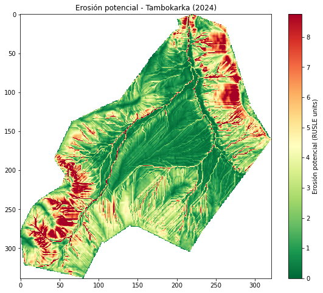

```
Media: 2.955275
Máximo: 69.75386
Percentil 95: 8.75976696014404
```

```python
# Visualización y resumen estadístico
plt.figure(figsize=(10, 8))
plt.imshow(A, cmap='RdYlGn_r', vmin=0, vmax=np.nanpercentile(A, 95))
plt.colorbar(label='Erosión potencial (RUSLE units)')
plt.title('Erosión potencial - Tambokarka (2024)')
plt.show()

# Estadísticas básicas
print("Media:", np.nanmean(A))
print("Máximo:", np.nanmax(A))
print("Percentil 95:", np.nanpercentile(A, 95))
```

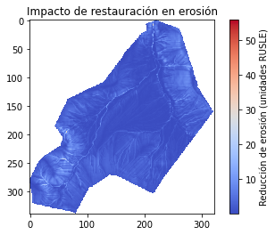

```python
## Escenario restaurado (comparativo)
#para simular el impacto de restauración
# Escenario restaurado con mejor cobertura
C_restaurado = 0.1
A_restaurado = R * K * LS * C_restaurado * P

# Diferencia (reducción de erosión)
delta = A - A_restaurado

plt.imshow(delta, cmap='coolwarm')
plt.colorbar(label='Reducción de erosión (unidades RUSLE)')
plt.title('Impacto de restauración en erosión')
plt.show()
```

## RUSLE con NDVI

```python
import rasterio
import numpy as np
from rasterio.enums import Resampling
from rasterio.plot import show
import matplotlib.pyplot as plt

# ==========================
# 🔹 1. RUTAS DE ARCHIVOS
# ==========================
path_R = r"F:\proy vicuna\R_anual_2024.tif"     # erosividad de lluvia (de GEE)
path_LS = r"F:\proy vicuna\dron_10m\LS_10m.tif"          # factor topográfico LS
path_C = r"F:\proy vicuna\indices_10m\NDVI_10m.tif"  # tu NDVI reproyectado a 10m
path_P = None  # Si no tienes raster P, deja None
```

```python
# 🔹 2. FUNCIÓN PARA LEER Y REPROYECTAR
# ==========================
def read_and_match(ref_path, other_path):
    with rasterio.open(ref_path) as ref:
        ref_meta = ref.meta.copy()
        with rasterio.open(other_path) as src:
            data = src.read(
                1,
                out_shape=(ref.height, ref.width),
                resampling=Resampling.bilinear
            )
    return data, ref_meta

# ==========================
# 🔹 3. LEER DATOS
# ==========================
R, meta = read_and_match(path_LS, path_R)  # igualar resolución con LS
LS, _ = read_and_match(path_LS, path_LS)
NDVI, _ = read_and_match(path_LS, path_C)
```

```python
# 🔹 4. CALCULAR FACTOR C
# ==========================
alpha, beta = 2.0, 1.0
NDVI = np.clip(NDVI, -1, 0.9999)
C = np.exp(-alpha * NDVI / (beta - NDVI))
C = np.clip(C, 0, 1)

# ==========================
# 🔹 5. FACTOR P (constante si no hay raster)
# ==========================
if path_P:
    P, _ = read_and_match(path_LS, path_P)
else:
    P = np.ones_like(R)

# ==========================
# 🔹 6. CÁLCULO DE LA EROSIÓN (A)
# ==========================
A = R * LS * C * P
A[A <= 0] = np.nan
```

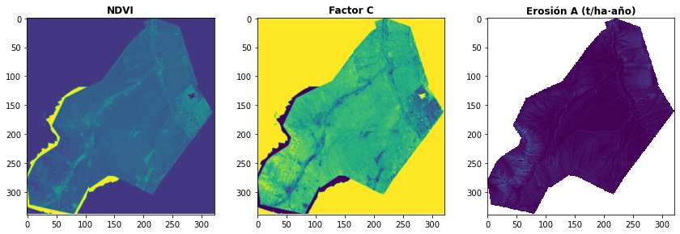

```python
# 🔹 7. GUARDAR RESULTADO
# ==========================
meta.update(dtype=rasterio.float32, count=1)
with rasterio.open(r"F:\proy vicuna\A_erosion_2024.tif", "w", **meta) as dst:
    dst.write(A.astype(rasterio.float32), 1)

# ==========================
# 🔹 8. VISUALIZACIÓN RÁPIDA
# ==========================
fig, ax = plt.subplots(1, 3, figsize=(12, 4))
show(NDVI, ax=ax[0], title="NDVI")
show(C, ax=ax[1], title="Factor C")
show(A, ax=ax[2], title="Erosión A (t/ha·año)")
plt.tight_layout()
plt.show()
```

## Cortar imagen fit por otro tif

```
✅ Raster recortado guardado en: F:\proy vicuna\A_erosion_2024_clip.tif
```

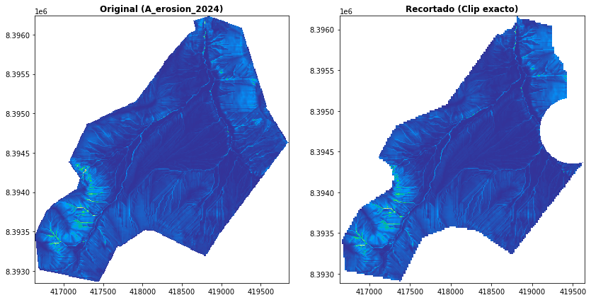

```python
import rasterio
from rasterio.mask import mask
from rasterio.features import geometry_mask
import geopandas as gpd
import numpy as np
import matplotlib.pyplot as plt

# === Rutas ===
raster_fp = r"F:\proy vicuna\A_erosion_2024.tif"
mask_fp   = r"F:\proy vicuna\mapa_CARBONO_STOCK.tif"
out_fp    = r"F:\proy vicuna\A_erosion_2024_clip.tif"

# === 1) Abrir el raster máscara y extraer geometría de zonas válidas ===
with rasterio.open(mask_fp) as src_mask:
    mask_data = src_mask.read(1)
    mask_affine = src_mask.transform
    mask_crs = src_mask.crs

    # Crear geometría (polígonos) de las zonas con datos válidos
    mask_geom = []
    for geom, val in rasterio.features.shapes(mask_data, transform=mask_affine):
        if val != src_mask.nodata and not np.isnan(val):
            mask_geom.append(geom)

# === 2) Recortar el raster original usando esas geometrías ===
with rasterio.open(raster_fp) as src:
    if src.crs != mask_crs:
        print("⚠️ CRS diferente, reproyectando máscara...")
        from rasterio.warp import transform_geom
        mask_geom = [transform_geom(mask_crs, src.crs, g) for g in mask_geom]

    out_image, out_transform = mask(src, mask_geom, crop=True)
    out_meta = src.meta.copy()

# === 3) Guardar raster recortado ===
out_meta.update({
    "driver": "GTiff",
    "height": out_image.shape[1],
    "width": out_image.shape[2],
    "transform": out_transform
})

with rasterio.open(out_fp, "w", **out_meta) as dest:
    dest.write(out_image)

print("✅ Raster recortado guardado en:", out_fp)

# === 4) Visualización ===
fig, ax = plt.subplots(1, 2, figsize=(12,6))

with rasterio.open(raster_fp) as src:
    rasterio.plot.show(src, ax=ax[0], title="Original (A_erosion_2024)", cmap="terrain")

with rasterio.open(out_fp) as clipped:
    rasterio.plot.show(clipped, ax=ax[1], title="Recortado (Clip exacto)", cmap="terrain")

plt.tight_layout()
plt.show()
```

## clasificación ambiental multicriterio (MCDA) a partir de tres capas raster continuas.

```python
# Paso 1: Definir umbrales “Alto/Bajo”
import rasterio
import numpy as np
import matplotlib.pyplot as plt
from rasterio.enums import Resampling
from rasterio.plot import show
import pandas as pd

# ==========================
# 🔹 1. RUTAS DE LOS RASTERS
# ==========================
path_erosion = r"F:\proy vicuna\A_erosion_2024_clip.tif"
path_carbono = r"F:\proy vicuna\mapa_CARBONO_STOCK.tif"
path_dry = r"F:\proy vicuna\mapa_DRY_WEIGHT.tif"
output_path = r"F:\proy vicuna\clasificacion_SERFOR_2024_v2.tif"

# ==========================
# 🔹 2. FUNCIÓN PARA REPROYECTAR Y EMPAREJAR RASTERS
# ==========================
def read_and_match(ref_path, other_path):
    with rasterio.open(ref_path) as ref:
        ref_meta = ref.meta.copy()
        with rasterio.open(other_path) as src:
            data = src.read(
                1,
                out_shape=(ref.height, ref.width),
                resampling=Resampling.bilinear
            )
    return data, ref_meta
```

```python
# 🔹 3. LEER Y AJUSTAR TODOS LOS RASTERS
# ==========================
erosion, meta = read_and_match(path_erosion, path_erosion)
carbono, _ = read_and_match(path_erosion, path_carbono)
dry, _ = read_and_match(path_erosion, path_dry)

# ==========================
# 🔹 4. LIMPIEZA DE DATOS
# ==========================
mask_invalid = (erosion <= 0) | (carbono <= 0) | (dry <= 0)
erosion[mask_invalid] = np.nan
carbono[mask_invalid] = np.nan
dry[mask_invalid] = np.nan

# ==========================
# 🔹 5. CALCULAR UMBRALES (MEDIANA)
# ==========================
th_erosion = np.nanmedian(erosion)
th_carbono = np.nanmedian(carbono)
th_dry = np.nanmedian(dry)

print("Umbrales automáticos:")
print(f" - Carbono Stock (ALTO > {th_carbono:.2f})")
print(f" - Dry Weight (ALTO > {th_dry:.2f})")
print(f" - Erosión (ALTO > {th_erosion:.2f})")
```

```
Umbrales automáticos:
 - Carbono Stock (ALTO > 178.76)
 - Dry Weight (ALTO > 111.60)
 - Erosión (ALTO > 78.50)
```

```python
# 🔹 6. CLASIFICAR EN ALTO / BAJO
# ==========================
C_high = carbono > th_carbono
D_high = dry > th_dry
E_high = erosion > th_erosion

# ==========================
# 🔹 7. APLICAR LAS 8 REGLAS DE DECISIÓN
# ==========================
# Creamos una matriz de clasificación (valores del 1 al 8)
clasificacion = np.full_like(erosion, np.nan)

# Grupo A: Suelo saludable (Carbono alto)
clasificacion[C_high & D_high & ~E_high] = 1  # Regla 1: Ecosistema Ideal
clasificacion[C_high & D_high & E_high] = 2   # Regla 2: Protección Crítica
clasificacion[C_high & ~D_high & ~E_high] = 3  # Regla 3: Sobrepastoreo leve
clasificacion[C_high & ~D_high & E_high] = 4   # Regla 4: Alerta Erosión

# Grupo B: Suelo degradado (Carbono bajo)
clasificacion[~C_high & ~D_high & ~E_high] = 5  # Regla 5: Pastizal degradado
clasificacion[~C_high & ~D_high & E_high] = 6   # Regla 6: Restauración crítica
clasificacion[~C_high & D_high] = 7             # Regla 7–8: Zonas anómalas
```

```python
# 🔹 8. GUARDAR RASTER FINAL
# ==========================
meta.update(dtype=rasterio.float32, count=1)
with rasterio.open(output_path, "w", **meta) as dst:
    dst.write(clasificacion.astype(rasterio.float32), 1)

print(f"\n✅ Mapa de clasificación guardado en: {output_path}")
```

[output not shown]

[figure not shown]

```
Resumen de áreas clasificadas:
   Código                                      Categoría  Pixeles
0     1.0                Ecosistema Ideal (Conservación)     4092
1     2.0                  Protección Crítica (No tocar)     3832
2     3.0         Sobrepastoreo leve (Manejo y descanso)    10241
3     4.0           Alerta de Erosión (Retiro inmediato)     5497
4     5.0   Pastizal Degradado (Restauración productiva)    55251
5     6.0  Restauración Crítica (Obras físicas urgentes)     4087
6     7.0              Zona Anómala (Verificar en campo)    15728
```

```python
# 🔹 9. LEYENDA Y VISUALIZACIÓN
# ==========================
leyenda = {
    1: "Ecosistema Ideal (Conservación)",
    2: "Protección Crítica (No tocar)",
    3: "Sobrepastoreo leve (Manejo y descanso)",
    4: "Alerta de Erosión (Retiro inmediato)",
    5: "Pastizal Degradado (Restauración productiva)",
    6: "Restauración Crítica (Obras físicas urgentes)",
    7: "Zona Anómala (Verificar en campo)"
}

# Crear mapa con colores
colores = {
    1: "#2ca02c",  # verde intenso
    2: "#ff7f0e",  # naranja
    3: "#98df8a",  # verde claro
    4: "#d62728",  # rojo
    5: "#c7c7c7",  # gris
    6: "#8c564b",  # marrón oscuro
    7: "#17becf"   # celeste
}

fig, ax = plt.subplots(figsize=(8, 6))
unique_vals = np.unique(clasificacion[~np.isnan(clasificacion)])

for val in unique_vals:
    mask = clasificacion == val
    color = colores.get(val, "white")
    ax.imshow(np.where(mask, val, np.nan), cmap=None, alpha=0.8)

plt.title("Clasificación SERFOR 2024 (Reglas de decisión)")
plt.axis("off")
plt.show()

# Crear tabla resumen
valores, conteos = np.unique(clasificacion[~np.isnan(clasificacion)], return_counts=True)
tabla = pd.DataFrame({
    "Código": valores,
    "Categoría": [leyenda[int(v)] for v in valores],
    "Pixeles": conteos
})
print("\nResumen de áreas clasificadas:")
print(tabla)
```

## Version modificada

```python
import rasterio
import numpy as np
import matplotlib.pyplot as plt
from matplotlib.colors import ListedColormap, BoundaryNorm
import pandas as pd
from rasterio.enums import Resampling

# ==========================
# 🔹 1. RUTAS
# ==========================
path_erosion = r"F:\proy vicuna\A_erosion_2024_clip.tif"
path_carbono = r"F:\proy vicuna\mapa_CARBONO_STOCK.tif"
path_dry = r"F:\proy vicuna\mapa_DRY_WEIGHT.tif"
output_path = r"F:\proy vicuna\clasificacion_SERFOR_2024_v4.tif"
csv_resumen = r"F:\proy vicuna\resumen_clasificacion_SERFOR_2024_v4.csv"

# ==========================
# 🔹 2. FUNCIONES
# ==========================
def read_and_match(ref_path, other_path):
    with rasterio.open(ref_path) as ref:
        ref_meta = ref.meta.copy()
        with rasterio.open(other_path) as src:
            data = src.read(
                1,
                out_shape=(ref.height, ref.width),
                resampling=Resampling.bilinear
            )
    return data, ref_meta

# ==========================
# 🔹 3. LECTURA DE DATOS
# ==========================
erosion, meta = read_and_match(path_erosion, path_erosion)
carbono, _ = read_and_match(path_erosion, path_carbono)
dry, _ = read_and_match(path_erosion, path_dry)

# Limpieza
mask_invalid = (erosion <= 0) | (carbono <= 0) | (dry <= 0)
erosion[mask_invalid] = np.nan
carbono[mask_invalid] = np.nan
dry[mask_invalid] = np.nan

# ==========================
# 🔹 4. UMBRALES AUTOMÁTICOS
# ==========================
th_erosion = np.nanmedian(erosion)
th_carbono = np.nanmedian(carbono)
th_dry = np.nanmedian(dry)

print("Umbrales automáticos:")
print(f" - Carbono Stock (ALTO > {th_carbono:.2f})")
print(f" - Dry Weight (ALTO > {th_dry:.2f})")
print(f" - Erosión (ALTO > {th_erosion:.2f})")
```

```
Umbrales automáticos:
 - Carbono Stock (ALTO > 178.76)
 - Dry Weight (ALTO > 111.60)
 - Erosión (ALTO > 78.50)
```

```python
# 🔹 5. CLASIFICACIÓN
# ==========================
C_high = carbono > th_carbono
D_high = dry > th_dry
E_high = erosion > th_erosion

clasificacion = np.full_like(erosion, np.nan)

# Grupo A: Suelo saludable
clasificacion[C_high & D_high & ~E_high] = 1
clasificacion[C_high & D_high & E_high] = 2
clasificacion[C_high & ~D_high & ~E_high] = 3
clasificacion[C_high & ~D_high & E_high] = 4

# Grupo B: Suelo degradado
clasificacion[~C_high & ~D_high & ~E_high] = 5
clasificacion[~C_high & ~D_high & E_high] = 6
clasificacion[~C_high & D_high] = 7

# ==========================
# 🔹 6. GUARDAR RASTER FINAL
# ==========================
meta.update(dtype=rasterio.float32, count=1)
with rasterio.open(output_path, "w", **meta) as dst:
    dst.write(clasificacion.astype(rasterio.float32), 1)

print(f"\n✅ Mapa de clasificación guardado en: {output_path}")
```

[output not shown]

```python
# 🔹 7. CÁLCULO DE ÁREAS Y PORCENTAJES
# ==========================
res_x, res_y = abs(meta['transform'][0]), abs(meta['transform'][4])
area_pixel_m2 = res_x * res_y
area_pixel_ha = area_pixel_m2 / 10000

valores, conteos = np.unique(clasificacion[~np.isnan(clasificacion)], return_counts=True)
area_ha = conteos * area_pixel_ha
area_total = np.sum(area_ha)
porcentaje = (area_ha / area_total) * 100

leyenda = {
    1: "Ecosistema Ideal (Conservación)",
    2: "Protección Crítica (No tocar)",
    3: "Sobrepastoreo leve (Manejo y descanso)",
    4: "Alerta de Erosión (Retiro inmediato)",
    5: "Pastizal Degradado (Restauración productiva)",
    6: "Restauración Crítica (Obras físicas urgentes)",
    7: "Zona Anómala (Verificar en campo)"
}

tabla = pd.DataFrame({
    "Código": valores.astype(int),
    "Categoría": [leyenda[int(v)] for v in valores],
    "Pixeles": conteos,
    "Área_ha": area_ha,
    "%_Área": porcentaje
}).sort_values("Código")

tabla.to_csv(csv_resumen, index=False, encoding="utf-8-sig")
print("\n📊 Resumen de áreas guardado en CSV:")
print(csv_resumen)
print(tabla)
```

[output not shown]

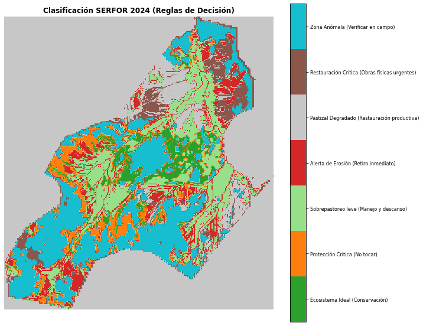

```python
# 🔹 8. MEJOR VISUALIZACIÓN
# ==========================
colores = ["#2ca02c", "#ff7f0e", "#98df8a", "#d62728", "#c7c7c7", "#8c564b", "#17becf"]
cmap = ListedColormap(colores)
bounds = [0.5, 1.5, 2.5, 3.5, 4.5, 5.5, 6.5, 7.5]
norm = BoundaryNorm(bounds, cmap.N)

fig, ax = plt.subplots(figsize=(10, 8))
img = ax.imshow(clasificacion, cmap=cmap, norm=norm)
ax.set_title("Clasificación SERFOR 2024 (Reglas de Decisión)", fontsize=12, fontweight="bold")
ax.axis("off")

# Barra de leyenda
cbar = plt.colorbar(img, ax=ax, boundaries=bounds, ticks=np.arange(1, 8))
cbar.ax.set_yticklabels([leyenda[i] for i in range(1, 8)])
cbar.ax.tick_params(labelsize=8)

plt.tight_layout()
plt.show()
```

```
✅ Raster recortado guardado en: F:\proy vicuna\SERFOR_2024_v2_clip.tif
```

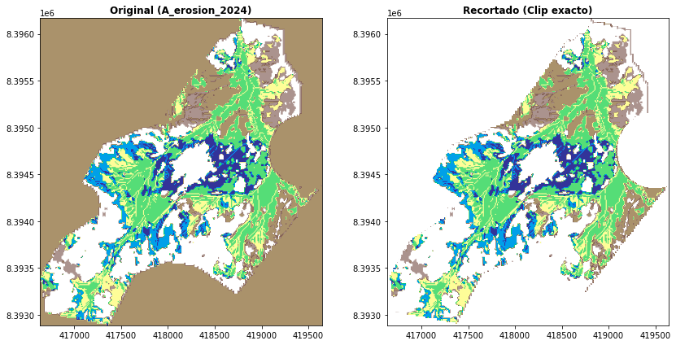

```python
import rasterio
from rasterio.mask import mask
from rasterio.features import geometry_mask
import geopandas as gpd
import numpy as np
import matplotlib.pyplot as plt

# === Rutas ===
raster_fp = r"F:\proy vicuna\clasificacion_SERFOR_2024_v2.tif"
mask_fp   = r"F:\proy vicuna\mapa_CARBONO_STOCK.tif"
out_fp    = r"F:\proy vicuna\SERFOR_2024_v2_clip.tif"

# === 1) Abrir el raster máscara y extraer geometría de zonas válidas ===
with rasterio.open(mask_fp) as src_mask:
    mask_data = src_mask.read(1)
    mask_affine = src_mask.transform
    mask_crs = src_mask.crs

    # Crear geometría (polígonos) de las zonas con datos válidos
    mask_geom = []
    for geom, val in rasterio.features.shapes(mask_data, transform=mask_affine):
        if val != src_mask.nodata and not np.isnan(val):
            mask_geom.append(geom)

# === 2) Recortar el raster original usando esas geometrías ===
with rasterio.open(raster_fp) as src:
    if src.crs != mask_crs:
        print("⚠️ CRS diferente, reproyectando máscara...")
        from rasterio.warp import transform_geom
        mask_geom = [transform_geom(mask_crs, src.crs, g) for g in mask_geom]

    out_image, out_transform = mask(src, mask_geom, crop=True)
    out_meta = src.meta.copy()

# === 3) Guardar raster recortado ===
out_meta.update({
    "driver": "GTiff",
    "height": out_image.shape[1],
    "width": out_image.shape[2],
    "transform": out_transform
})

with rasterio.open(out_fp, "w", **out_meta) as dest:
    dest.write(out_image)

print("✅ Raster recortado guardado en:", out_fp)

# === 4) Visualización ===
fig, ax = plt.subplots(1, 2, figsize=(12,6))

with rasterio.open(raster_fp) as src:
    rasterio.plot.show(src, ax=ax[0], title="Original (A_erosion_2024)", cmap="terrain")

with rasterio.open(out_fp) as clipped:
    rasterio.plot.show(clipped, ax=ax[1], title="Recortado (Clip exacto)", cmap="terrain")

plt.tight_layout()
plt.show()
```

```
Umbrales automáticos (medianas):
 - Carbono ALTO si > 178.76
 - Dry Weight ALTO si > 111.60
 - Erosividad ALTA si > 78.50

✅ Mapa de clasificación guardado en: F:\proy vicuna\clasificacion_SERFOR_2024_v5.tif

📊 Resumen de áreas guardado en CSV (sin categoría 0):
F:\proy vicuna\resumen_clasificacion_SERFOR_2024_v5.csv
   Código                                          Categoría  Pixeles  \
0       1                     Ecosistema saludable y estable     4092
1       2                Suelo sano pero vegetación reducida     3832
2       3  Alta cobertura, baja productividad (estrés híd...    10241
3       4                         Pérdida de carbono inicial     5243
4       5                 Suelo degradado con baja cobertura    10485
5       6             Vegetación intermitente / pisoteo alto    55251
6       7                  Degradación severa / erosión alta     4087

   Área_ha     %_Área
0    40.92   4.144721
1    38.32   3.881371
2   102.41  10.372944
3    52.43   5.310550
4   104.85  10.620088
5   552.51  55.962847
6    40.87   4.139656

⚪ No clasificado: 54.97 ha (5.57%)
→ No se incluyó en el CSV principal.
```

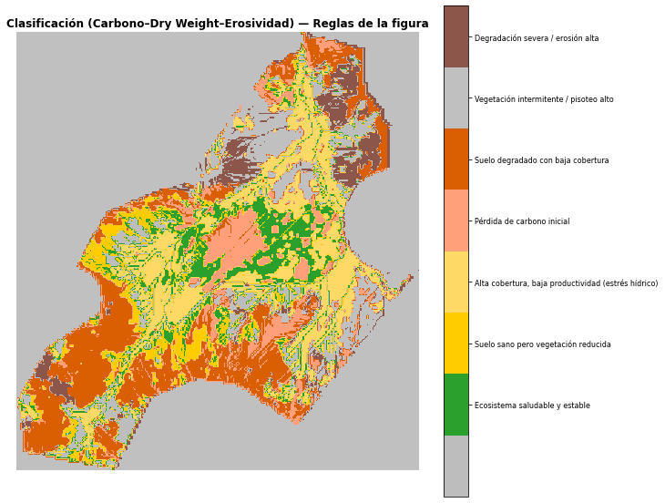

```python
import rasterio
import numpy as np
import matplotlib.pyplot as plt
from matplotlib.colors import ListedColormap, BoundaryNorm
import pandas as pd
from rasterio.enums import Resampling

# ==========================
# 🔹 1. RUTAS (EDITAR SI ES NECESARIO)
# ==========================
path_erosion = r"F:\proy vicuna\A_erosion_2024_clip.tif"           # Erosividad
path_carbono = r"F:\proy vicuna\mapa_CARBONO_STOCK.tif"            # Carbono
path_dry     = r"F:\proy vicuna\mapa_DRY_WEIGHT.tif"               # Dry Weight
output_path  = r"F:\proy vicuna\clasificacion_SERFOR_2024_v5.tif"
csv_resumen  = r"F:\proy vicuna\resumen_clasificacion_SERFOR_2024_v5.csv"



# ==========================
# 🔹 2. FUNCIONES
# ==========================
def read_and_match(ref_path, other_path):
    """Lee 'other_path' y lo re-muestrea a la grilla de 'ref_path'."""
    with rasterio.open(ref_path) as ref:
        ref_meta = ref.meta.copy()
        with rasterio.open(other_path) as src:
            data = src.read(
                1,
                out_shape=(ref.height, ref.width),
                resampling=Resampling.bilinear  # continuo
            )
    return data, ref_meta

# ==========================
# 🔹 3. LECTURA DE DATOS
# ==========================
# Usamos erosión como referencia espacial (grilla/transform/CRS)
erosion, meta = read_and_match(path_erosion, path_erosion)  # erosividad
carbono, _    = read_and_match(path_erosion, path_carbono)  # carbono
dry, _        = read_and_match(path_erosion, path_dry)      # dry weight

# Limpieza básica (valores no válidos se dejan en NaN)
mask_invalid = (erosion <= 0) | (carbono <= 0) | (dry <= 0)
erosion = np.where(mask_invalid, np.nan, erosion)
carbono = np.where(mask_invalid, np.nan, carbono)
dry     = np.where(mask_invalid, np.nan, dry)

# ==========================
# 🔹 4. UMBRALES AUTOMÁTICOS (MEDIANA)
# ==========================
th_carbono = np.nanmedian(carbono)
th_dry     = np.nanmedian(dry)
th_erosion = np.nanmedian(erosion)

print("Umbrales automáticos (medianas):")
print(f" - Carbono ALTO si > {th_carbono:.2f}")
print(f" - Dry Weight ALTO si > {th_dry:.2f}")
print(f" - Erosividad ALTA si > {th_erosion:.2f}")

# Binarización según tabla (1=alto, 0=bajo)
C = (carbono > th_carbono)   # Carbono
D = (dry     > th_dry)       # Dry Weight
E = (erosion > th_erosion)   # Erosividad (ALTA=1)

# ==========================
# 🔹 5. CLASIFICACIÓN SEGÚN LA FIGURA (7 CASOS)
# ==========================
clasificacion = np.full_like(erosion, np.nan, dtype=float)

# Casos de la tabla (exactos):
clasificacion[ C &  D & ~E] = 1  # Ecosistema saludable y estable
clasificacion[ C &  D &  E] = 2  # Suelo sano pero vegetación reducida
clasificacion[ C & ~D & ~E] = 3  # Alta cobertura, baja productividad (estrés hídrico)
clasificacion[~C &  D & ~E] = 4  # Pérdida de carbono inicial
clasificacion[~C &  D &  E] = 5  # Suelo degradado con baja cobertura
clasificacion[~C & ~D & ~E] = 6  # Vegetación intermitente / pisoteo alto
clasificacion[~C & ~D &  E] = 7  # Degradación severa / erosión alta

# (Opcional) Marcar combinaciones no cubiertas por la tabla como 0
# Ej.: C & ~D & E  -> 0 (No clasificado)
no_definido = np.isnan(clasificacion) & (~mask_invalid)
clasificacion[no_definido] = 0  # No clasificado

# ==========================
# 🔹 6. GUARDAR RASTER FINAL
# ==========================
meta.update(dtype=rasterio.float32, count=1, nodata=np.nan)
with rasterio.open(output_path, "w", **meta) as dst:
    dst.write(clasificacion.astype(rasterio.float32), 1)

print(f"\n✅ Mapa de clasificación guardado en: {output_path}")

# ==========================
# 🔹 7. CÁLCULO DE ÁREAS Y PORCENTAJES
# ==========================
res_x, res_y = abs(meta['transform'][0]), abs(meta['transform'][4])
area_pixel_m2 = res_x * res_y
area_pixel_ha = area_pixel_m2 / 10000

valores, conteos = np.unique(clasificacion[~np.isnan(clasificacion)], return_counts=True)
area_ha = conteos * area_pixel_ha
area_total = np.sum(area_ha)
porcentaje = (area_ha / area_total) * 100

# Diccionario principal (sin 0)
leyenda = {
    1: "Ecosistema saludable y estable",
    2: "Suelo sano pero vegetación reducida",
    3: "Alta cobertura, baja productividad (estrés hídrico)",
    4: "Pérdida de carbono inicial",
    5: "Suelo degradado con baja cobertura",
    6: "Vegetación intermitente / pisoteo alto",
    7: "Degradación severa / erosión alta"
}

# 🟢 Filtramos los valores distintos de 0
mask_validos = valores != 0
valores_validos = valores[mask_validos]
conteos_validos = conteos[mask_validos]
area_ha_validos = area_ha[mask_validos]
porcentaje_validos = porcentaje[mask_validos]

# Crear tabla solo con las categorías válidas
tabla = pd.DataFrame({
    "Código": valores_validos.astype(int),
    "Categoría": [leyenda[int(v)] for v in valores_validos],
    "Pixeles": conteos_validos,
    "Área_ha": area_ha_validos,
    "%_Área": porcentaje_validos
}).sort_values("Código")

tabla.to_csv(csv_resumen, index=False, encoding="utf-8-sig")
print("\n📊 Resumen de áreas guardado en CSV (sin categoría 0):")
print(csv_resumen)
print(tabla)

# Guardar también resumen de no clasificados aparte
if 0 in valores:
    idx_0 = np.where(valores == 0)[0][0]
    area_nc = area_ha[idx_0]
    porc_nc = porcentaje[idx_0]
    print(f"\n⚪ No clasificado: {area_nc:.2f} ha ({porc_nc:.2f}%)")
    print("→ No se incluyó en el CSV principal.")

# ==========================
# 🔹 8. VISUALIZACIÓN
# ==========================
colores = {
    0: "#bdbdbd",  # gris para No clasificado
    1: "#2ca02c",  # verde
    2: "#ffcc00",  # amarillo fuerte
    3: "#ffd966",  # amarillo pálido
    4: "#ffa07a",  # salmón claro
    5: "#d95f02",  # naranja oscuro
    6: "#c0c0c0",  # gris claro
    7: "#8c564b"   # marrón
}

classes = [0,1,2,3,4,5,6,7]
cmap = ListedColormap([colores[k] for k in classes])
bounds = [c-0.5 for c in classes] + [7.5]
norm = BoundaryNorm(bounds, cmap.N)

fig, ax = plt.subplots(figsize=(10, 8))
img = ax.imshow(clasificacion, cmap=cmap, norm=norm)
ax.set_title("Clasificación (Carbono–Dry Weight–Erosividad) — Reglas de la figura",
             fontsize=12, fontweight="bold")
ax.axis("off")

# Barra de colores sin la categoría 0
cbar = plt.colorbar(img, ax=ax, boundaries=bounds, ticks=classes[1:])
cbar.ax.set_yticklabels([leyenda[i] for i in classes if i in leyenda])
cbar.ax.tick_params(labelsize=8)

plt.tight_layout()
plt.show()
```

```
✅ Raster recortado guardado en: F:\proy vicuna\clasificacion_SERFOR_2024_v5_clip.tif
```

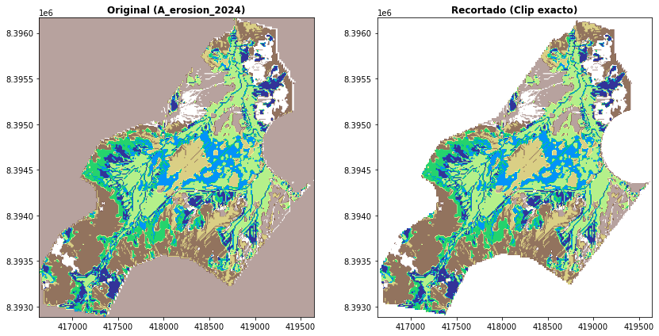

```python
import rasterio
from rasterio.mask import mask
from rasterio.features import geometry_mask
import geopandas as gpd
import numpy as np
import matplotlib.pyplot as plt

# === Rutas ===
raster_fp = r"F:\proy vicuna\clasificacion_SERFOR_2024_v5.tif"
mask_fp   = r"F:\proy vicuna\mapa_CARBONO_STOCK.tif"
out_fp    = r"F:\proy vicuna\clasificacion_SERFOR_2024_v5_clip.tif"

# === 1) Abrir el raster máscara y extraer geometría de zonas válidas ===
with rasterio.open(mask_fp) as src_mask:
    mask_data = src_mask.read(1)
    mask_affine = src_mask.transform
    mask_crs = src_mask.crs

    # Crear geometría (polígonos) de las zonas con datos válidos
    mask_geom = []
    for geom, val in rasterio.features.shapes(mask_data, transform=mask_affine):
        if val != src_mask.nodata and not np.isnan(val):
            mask_geom.append(geom)

# === 2) Recortar el raster original usando esas geometrías ===
with rasterio.open(raster_fp) as src:
    if src.crs != mask_crs:
        print("⚠️ CRS diferente, reproyectando máscara...")
        from rasterio.warp import transform_geom
        mask_geom = [transform_geom(mask_crs, src.crs, g) for g in mask_geom]

    out_image, out_transform = mask(src, mask_geom, crop=True)
    out_meta = src.meta.copy()

# === 3) Guardar raster recortado ===
out_meta.update({
    "driver": "GTiff",
    "height": out_image.shape[1],
    "width": out_image.shape[2],
    "transform": out_transform
})

with rasterio.open(out_fp, "w", **out_meta) as dest:
    dest.write(out_image)

print("✅ Raster recortado guardado en:", out_fp)

# === 4) Visualización ===
fig, ax = plt.subplots(1, 2, figsize=(12,6))

with rasterio.open(raster_fp) as src:
    rasterio.plot.show(src, ax=ax[0], title="Original (A_erosion_2024)", cmap="terrain")

with rasterio.open(out_fp) as clipped:
    rasterio.plot.show(clipped, ax=ax[1], title="Recortado (Clip exacto)", cmap="terrain")

plt.tight_layout()
plt.show()
```

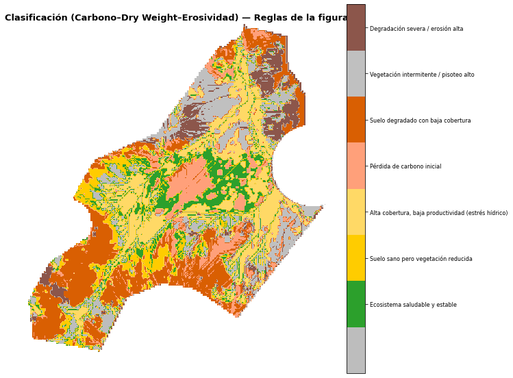

```python
import rasterio
import numpy as np
import matplotlib.pyplot as plt
from matplotlib.colors import ListedColormap, BoundaryNorm

# === Ruta del raster clasificado ===
path_raster = r"F:\proy vicuna\clasificacion_SERFOR_2024_v5_clip.tif"

# === Leer raster ===
with rasterio.open(path_raster) as src:
    clasificacion = src.read(1)
    meta = src.meta

# === Definir paleta de colores y leyenda ===
colores = {
    0: "#bdbdbd",  # gris - No clasificado
    1: "#2ca02c",  # verde - Ecosistema saludable
    2: "#ffcc00",  # amarillo fuerte - Suelo sano pero vegetación reducida
    3: "#ffd966",  # amarillo pálido - Alta cobertura, baja productividad
    4: "#ffa07a",  # salmón - Pérdida de carbono inicial
    5: "#d95f02",  # naranja - Suelo degradado con baja cobertura
    6: "#c0c0c0",  # gris claro - Vegetación intermitente / pisoteo alto
    7: "#8c564b"   # marrón - Degradación severa / erosión alta
}

leyenda = {
    1: "Ecosistema saludable y estable",
    2: "Suelo sano pero vegetación reducida",
    3: "Alta cobertura, baja productividad (estrés hídrico)",
    4: "Pérdida de carbono inicial",
    5: "Suelo degradado con baja cobertura",
    6: "Vegetación intermitente / pisoteo alto",
    7: "Degradación severa / erosión alta"
}

# === Configuración del color map ===
classes = [0, 1, 2, 3, 4, 5, 6, 7]
cmap = ListedColormap([colores[c] for c in classes])
bounds = [c - 0.5 for c in classes] + [7.5]
norm = BoundaryNorm(bounds, cmap.N)

# === Crear figura ===
fig, ax = plt.subplots(figsize=(10, 8))
img = ax.imshow(clasificacion, cmap=cmap, norm=norm)
ax.set_title("Clasificación (Carbono–Dry Weight–Erosividad) — Reglas de la figura",
             fontsize=13, fontweight="bold")
ax.axis("off")

# === Barra de colores ===
cbar = plt.colorbar(img, ax=ax, boundaries=bounds, ticks=classes[1:])
cbar.ax.set_yticklabels([leyenda[i] for i in classes if i in leyenda])
cbar.ax.tick_params(labelsize=8)

plt.tight_layout()
plt.show()
```